# Trabajo Final-Opción 2

Thelma Fratarelli, Beatriz Soria e Ignacio Luis Bastías

2023-12-27

Trabajo Final Diploma Universitario en Ciencias Sociales Computacionales y Humanidades Digitales

# Introducción

## Preparación de los datos

## Se cargan las librerías a emplear

```r
library(tidyverse)
library(tidytext)
library(tidymodels)
library(stm)
library(knitr)
library(themis)
# library(doParallel)
# library(topicmodels)
# library(tictoc)
# library(reshape2)
```

## Se carga el dataset de noticias provisto

```r
noticias <- read_csv('M5_corpus_medios.csv')
noticias |>
  slice(1:50) |>
  head()
```

| id | url | fecha | anio | mes | dia | medio | orientacion | titulo | texto |
| --- | --- | --- | --- | --- | --- | --- | --- | --- | --- |
| 51960 | https://www.clarin.com/viajes/copa-america-2019-cuesta-viajar-ver-semifinal-brasil-vs-argentina_0_odChhKZmG.html | 2019-07-01 | 2019 | 7 | 1 | clarin | + conservador | Copa América 2019: cuánto cuesta viajar a ver la semifinal Brasil vs Argentina | Argentina arrancó a paso flojo en esta Copa América 2019, pero de a poco fue superando obstáculos y rivales y llegó a la semifinal. El partido de mañana no será uno más: la Selección tendrá enfrente a… |
| 52024 | https://www.clarin.com/policiales/robo-policia-noche-boliches-crimen-sangre-fria_0_0bTwBQA1I.html | 2019-07-01 | 2019 | 7 | 1 | clarin | + conservador | Robo a un policía, noche de boliches y crimen a sangre fría | La secuencia final quedó filmada por las cámaras de seguridad de la parroquia Santa Mónica. Delante de un boy scout que lo esperaba, Ernesto Cavazza (80) fue asesinado de un disparo que le ingresó por… |
| 52023 | https://www.clarin.com/rural/invernada-vientres-valen-mismo-vaca-gorda_0_AbaNr8RLi.html | 2019-07-01 | 2019 | 7 | 1 | clarin | + conservador | Invernada: ¿por qué los vientres valen lo mismo que la vaca gorda? | La semana pasada, ya en el cierre de la zafra 2019, se vieron varios remates importantes en varias localidades de la provincia de Buenos Aires, Córdoba y Santa Fe, sumando un volumen y una calidad poc… |
| 52095 | http://luz.perfil.com/2019/07/01/horoscopo-de-la-semana-103/ | 2019-07-01 | 2019 | 7 | 1 | perfil | neutro | Article `download()` failed with 404 Client Error: Not Found for url: http://luz.perfil.com/2019/07/01/horoscopo-de-la-semana-103/ on URL http://luz.perfil.com/2019/07/01/horoscopo-de-la-semana-103/ | Article `download()` failed with 404 Client Error: Not Found for url: http://luz.perfil.com/2019/07/01/horoscopo-de-la-semana-103/ on URL http://luz.perfil.com/2019/07/01/horoscopo-de-la-semana-103/ |
| 51863 | https://www.perfil.com/noticias/politica/cierran-la-causa-de-la-denuncia-de-miriam-quiroga-contra-los-kirchner.phtml | 2019-07-01 | 2019 | 7 | 1 | perfil | neutro | Cierran la causa de la denuncia de Miriam Quiroga contra los Kirchner | martes 13 marzo, 2018\r\n\r\nLa Cámara de Casación cerró una causa en la que se investigaron declaraciones de la supuesta secretaria de Néstor Kirchner, Miriam Quiroga, y dejó firme la decisión del ju… |
| 52087 | https://exitoina.perfil.com/noticias/rating/telefe-gano-junio-pero-la-tv-publica-tuvo-el-programa-mas-visto.phtml | 2019-07-01 | 2019 | 7 | 1 | perfil | neutro | Telefe ganó junio, pero la TV Pública tuvo el programa más visto | Con el cierre de las mediciones de junio, Telefe ratificó su liderazgo en el rating al ganar nuevamente el mes. Sin embargo, hubo alegrías para todos, ya que El Trece se adueñó del prime time de lunes… |

# Preprocesamiento de los datos

## Construimos la tabla de tokens del texto

```r
#Armado del listado de noticias que no contienen texto
noticias_vacias <- noticias |>
  filter(is.na(texto))

# Uso de anti_join para eliminar esas noticias de la base "noticias"
noticias <- noticias |>
  anti_join(noticias_vacias, by = c("titulo" = "titulo"))

# Armado del listado de noticias que tuvieron errores en el webscrapeo, ya que inician con "Article # download()' failed with" o con 'NoneType' object has no attribute 'find_all'

noticias_mal_descargadas <- noticias |>
  # El ^ antes de artículo es una expresión regular para marcar que debe buscarse al inicio del título
  filter(str_detect(titulo, "^'NoneType'|^Article"))

# Usa anti_join para eliminar esas noticias de la base "noticias"
noticias <- noticias |>
  anti_join(noticias_mal_descargadas, by = c("titulo" = "titulo"))

noticias <- noticias |>
  # Elimina puntuación y valores numéros y, posteriormente, lleva todo a minúsculas
  mutate(texto = tolower(gsub("[[:punct:]0-9]", "", texto))) %>%
  # Elimina múltiples espaciados erróneamente ingresados
  mutate(texto = str_squish(texto))

# Arma el listado de noticias que, después de limpieza de caracteres, se considera que son demasiado cortas y producen "ruido" a la hora de evaluar las term frequency (TF)

noticias_cortas <- noticias |>
  # "\\S+" es la expresión regular para detectar palabras con un espacio
  filter(str_count(texto, "\\S+") < 40)

# Usa anti_join para eliminar esas noticias de la base "noticias"
noticias <- noticias |>
  anti_join(noticias_cortas, by = c("titulo" = "titulo"))

# Arma el listado de noticias de La Nación que tuvieron errores en el webscraping, ya que inician con "envía tu comentario ver legales los comentarios publicados son"

noticias_error_ln <- noticias |>
  filter(str_detect(texto, "^envía tu comentario ver legales los comentarios publicados son"))

# Usa anti_join para eliminar esas noticias de la base "noticias"
noticias <- noticias |>
  anti_join(noticias_error_ln, by = c("titulo" = "titulo"))
```

```r
noticias_tidy <- noticias %>%
  unnest_tokens(input = texto,
                output = word,
                token = "words")

noticias_tidy |>
  slice(1:50) |>
  print()
```

```
## # A tibble: 50 × 10
##       id url         fecha       anio   mes   dia medio orientacion titulo word
##    <dbl> <chr>       <date>     <dbl> <dbl> <dbl> <chr> <chr>       <chr>  <chr>
##  1 51960 https://ww… 2019-07-01  2019     7     1 clar… + conserva… Copa … arge…
##  2 51960 https://ww… 2019-07-01  2019     7     1 clar… + conserva… Copa … arra…
##  3 51960 https://ww… 2019-07-01  2019     7     1 clar… + conserva… Copa … a
##  4 51960 https://ww… 2019-07-01  2019     7     1 clar… + conserva… Copa … paso
##  5 51960 https://ww… 2019-07-01  2019     7     1 clar… + conserva… Copa … flojo
##  6 51960 https://ww… 2019-07-01  2019     7     1 clar… + conserva… Copa … en
##  7 51960 https://ww… 2019-07-01  2019     7     1 clar… + conserva… Copa … esta
##  8 51960 https://ww… 2019-07-01  2019     7     1 clar… + conserva… Copa … copa
##  9 51960 https://ww… 2019-07-01  2019     7     1 clar… + conserva… Copa … amér…
## 10 51960 https://ww… 2019-07-01  2019     7     1 clar… + conserva… Copa … pero
## # ℹ 40 more rows
```

## Cargamos el diccionario de stopwords y agregamos stopwords específicas

```r
stop_words <- read_csv("https://raw.githubusercontent.com/Alir3z4/stop-words/master/spanish.txt",
                       col_names=FALSE) %>%
        rename(word = X1) %>%
        mutate(word = stringi::stri_trans_general(word, "Latin-ASCII"))
stop_words |>
  slice(1:50) |>
  print()
```

```
## # A tibble: 50 × 1
##    word
##    <chr>
##  1 a
##  2 actualmente
##  3 adelante
##  4 ademas
##  5 afirmo
##  6 agrego
##  7 ahora
##  8 ahi
##  9 al
## 10 algo
## # ℹ 40 more rows
```

```r
stop_words <- stop_words %>%
  bind_rows(tibble(word = c("\tminutouno.com", "\tpáginai12", "a", "además", "además", "ahí", "allí", "ante", "año", "años", "así", "aún", "bajo", "comentar", "comentario", "como", "cómo", "compartir", "compartir", "con", "contra", "cronica.com.ar", "cronicacomar", "de", "desde", "después", "día", "días", "durante","él", "email", "embed", "en", "entre", "está", "están", "facebook", "fuente", "guardar", "gusta", "había", "hacia", "hasta", "jpe", "jpg", "l.l",      "leé", "loading", "mail", "más", "mediante", "minutouno.com", "nacion", "páginai", "páginai12", "para", "podría", "por", "pristupluk", "que", "qué", "según", "será", "si", "sí", "sin", "sobre", "sólo", "también", "tenía", "través", "twitter", "whatsapp", "fvazquezcronicacomar", "cronicavirales", "minutounocom", "telamla", "venturacrónica", "thieberger", "viercovich", "nersesian", "lucianobugner", "foglia", "jch", "failla", "foglia", "morenocrónica", "frannutti","bugner", "ernie", "zenteno", "nespolo", "marelli", "ll", "nutti", "massobrio","devito", "adami")))
```

## Procedemos a la eliminación de stopwords

```r
corpus_noticias <- noticias_tidy %>%
  anti_join(stop_words,
            by = c("word" = "word"))

# Elimina ambos archivos porque ya no son necesarios
rm(stop_words, noticias_tidy)

corpus_noticias |>
  slice(1:50) |>
  print()
```

```
## # A tibble: 50 × 10
##       id url         fecha       anio   mes   dia medio orientacion titulo word
##    <dbl> <chr>       <date>     <dbl> <dbl> <dbl> <chr> <chr>       <chr>  <chr>
##  1 51960 https://ww… 2019-07-01  2019     7     1 clar… + conserva… Copa … arge…
##  2 51960 https://ww… 2019-07-01  2019     7     1 clar… + conserva… Copa … arra…
##  3 51960 https://ww… 2019-07-01  2019     7     1 clar… + conserva… Copa … paso
##  4 51960 https://ww… 2019-07-01  2019     7     1 clar… + conserva… Copa … flojo
##  5 51960 https://ww… 2019-07-01  2019     7     1 clar… + conserva… Copa … copa
##  6 51960 https://ww… 2019-07-01  2019     7     1 clar… + conserva… Copa … amér…
##  7 51960 https://ww… 2019-07-01  2019     7     1 clar… + conserva… Copa … supe…
##  8 51960 https://ww… 2019-07-01  2019     7     1 clar… + conserva… Copa … obst…
##  9 51960 https://ww… 2019-07-01  2019     7     1 clar… + conserva… Copa … riva…
## 10 51960 https://ww… 2019-07-01  2019     7     1 clar… + conserva… Copa … llegó
## # ℹ 40 more rows
```

## Generamos una matriz token-por-fila para cada documento

```r
# Creamos un corpus centrado en los medios
corpus_tf_idf_medio <- corpus_noticias %>%
  count(medio, word,
        sort = TRUE) %>%
  bind_tf_idf(term = word,
              # Al poner como "document" el medio, el idf expresa cuánto usa más un medio que otro
              # ciertas palabras
              document = medio,
              n = n)

corpus_tf_idf_medio |>
  slice_max(n = 50,
            order_by = tf,
            # En caso de empates ("tie"), por default la función trae ambos valores; lo seteamos
            # para que sólo traiga uno
            with_ties = FALSE) |>
  print()
```

```
## # A tibble: 50 × 6
##    medio     word           n      tf   idf tf_idf
##    <chr>     <chr>      <int>   <dbl> <dbl>  <dbl>
##  1 telam     frente       183 0.00425     0      0
##  2 telam     presidente   177 0.00411     0      0
##  3 telam     gobierno     174 0.00404     0      0
##  4 telam     argentina    162 0.00376     0      0
##  5 pagina12  gobierno    1024 0.00363     0      0
##  6 pagina12  ciento       994 0.00352     0      0
##  7 lanacion  crédito      806 0.00348     0      0
##  8 perfil    argentina   1248 0.00345     0      0
##  9 minutouno gobierno     153 0.00339     0      0
## 10 clarin    argentina   1392 0.00334     0      0
## # ℹ 40 more rows
```

# Punto 1

```
- a) ¿Cuáles son las palabras más utilizadas en cada uno de los medios?
- b) ¿Pueden verse diferencias? (tener en cuenta las diferentes métricas trabajadas en el curso: tf, tf-idf, etc.)
- c) Generar las visualizaciones que considere más pertinentes para responder la pregunta
```

## Puntos a y b

### Armamos un corpus con las TF, IDF y las TF_IDF por medio

#### Buscamos las TF (las palabras más importantes/frecuentes)

```r
 top_words_tf <- corpus_tf_idf_medio %>%
  group_by(medio) %>%
  slice_max(n = 10,
            # Si seteamos otra variable en "order_by", obtenemos otra respuesta posible
            order_by = tf,
            with_ties = FALSE) %>%
  ungroup()

top_words_tf |>
  print()
```

```
## # A tibble: 80 × 6
##    medio  word           n      tf   idf tf_idf
##    <chr>  <chr>      <int>   <dbl> <dbl>  <dbl>
##  1 clarin argentina   1392 0.00334     0      0
##  2 clarin gobierno    1313 0.00315     0      0
##  3 clarin presidente  1118 0.00269     0      0
##  4 clarin país        1051 0.00253     0      0
##  5 clarin millones     876 0.00210     0      0
##  6 clarin nacional     734 0.00176     0      0
##  7 clarin fernández    719 0.00173     0      0
##  8 clarin macri        707 0.00170     0      0
##  9 clarin frente       680 0.00163     0      0
## 10 clarin semana       614 0.00148     0      0
## # ℹ 70 more rows
```

#### Buscamos las IDF (las palabras más informativas)

```r
top_words_idf <- corpus_tf_idf_medio %>%
  group_by(medio) %>%
  slice_max(n = 10,
            # Si seteamos otra variable en "order_by", obtenemos otra respuesta posible
            order_by = idf,
            with_ties = FALSE) %>%
  ungroup()

top_words_idf |>
  print()
```

```
## # A tibble: 80 × 6
##    medio  word            n        tf   idf    tf_idf
##    <chr>  <chr>       <int>     <dbl> <dbl>     <dbl>
##  1 clarin alces          29 0.0000697  2.08 0.000145
##  2 clarin emj            27 0.0000649  2.08 0.000135
##  3 clarin khashoggi      26 0.0000625  2.08 0.000130
##  4 clarin mattarella     22 0.0000529  2.08 0.000110
##  5 clarin dorothea       21 0.0000505  2.08 0.000105
##  6 clarin ps             21 0.0000505  2.08 0.000105
##  7 clarin lagaronne      20 0.0000481  2.08 0.0000999
##  8 clarin fujimori       18 0.0000432  2.08 0.0000899
##  9 clarin ravensbrück    18 0.0000432  2.08 0.0000899
## 10 clarin balcedo        17 0.0000408  2.08 0.0000849
## # ℹ 70 more rows
```

#### Buscamos las TF_IDF (la frecuencia ponderada o ajustada por la importancia que tiene en el corpus)

```r
top_words_tf_idf <- corpus_tf_idf_medio %>%
  group_by(medio) %>%
  slice_max(n = 10,
            # Si seteamos otra variable en "order_by", obtenemos otra respuesta posible
            order_by = tf_idf,
            with_ties = FALSE) %>%
  ungroup()

top_words_tf_idf  |>
  print()
```

```
## # A tibble: 80 × 6
##    medio  word          n        tf   idf   tf_idf
##    <chr>  <chr>     <int>     <dbl> <dbl>    <dbl>
##  1 clarin horóscopo    85 0.000204  1.39  0.000283
##  2 clarin regente      62 0.000149  1.39  0.000207
##  3 clarin mirá        516 0.00124   0.134 0.000166
##  4 clarin alces        29 0.0000697 2.08  0.000145
##  5 clarin afp         207 0.000497  0.288 0.000143
##  6 clarin clarín      421 0.00101   0.134 0.000135
##  7 clarin emj          27 0.0000649 2.08  0.000135
##  8 clarin khashoggi    26 0.0000625 2.08  0.000130
##  9 clarin merle        38 0.0000913 1.39  0.000127
## 10 clarin ap          112 0.000269  0.470 0.000126
## # ℹ 70 more rows
```

### C) Gráficos

#### Gráfico 1: Palabras más frecuentes (TF)

[figure not shown]

```r
top_words_tf$medio <- factor(top_words_tf$medio, levels = c("clarin", "cronica", "infobae", "lanacion", "pagina12", "perfil", "telam", "minutouno"), labels = c("Clarín", "Crónica", "Infobae", "La Nación", "Página 12", "Perfil", "Télam", "Minuto Uno"))

ggplot(top_words_tf, aes(x = tf,
                         y = word,
                         fill = medio)) +
  geom_col(width = 0.7) +
  scale_fill_discrete(name = "Medio") +
  labs(x = "Frecuencia (TF) cada 1000 palabras",
       y = "Término") +
  facet_wrap(~medio, scales = "free_y") +
  theme_minimal() +
  theme(legend.position = "none",
        axis.text.y = element_text(size = 7)) +  # Ajustar el tamaño de las etiquetas del eje y
  labs(title = "Las 10 palabras más utilizadas por medio",
       subtitle = "Julio - Septiembre 2019",
       caption = "Gráfico 1")
```

```r
top_words_idf %>%
  select(medio, word, idf) %>%
  kable(caption = "Top 10 palabras por IDF en cada medio")
```

Top 10 palabras por IDF en cada medio

| medio | word | idf |
| --- | --- | --- |
| clarin | alces | 2.079442 |
| clarin | emj | 2.079442 |
| clarin | khashoggi | 2.079442 |
| clarin | mattarella | 2.079442 |
| clarin | dorothea | 2.079442 |
| clarin | ps | 2.079442 |
| clarin | lagaronne | 2.079442 |
| clarin | fujimori | 2.079442 |
| clarin | ravensbrück | 2.079442 |
| clarin | balcedo | 2.079442 |
| cronica | infortunada | 2.079442 |
| cronica | garavelli | 2.079442 |
| cronica | malvivientes | 2.079442 |
| cronica | andanese | 2.079442 |
| cronica | epp | 2.079442 |
| cronica | etna | 2.079442 |
| cronica | gep | 2.079442 |
| cronica | lufkin | 2.079442 |
| cronica | paredescrónica | 2.079442 |
| cronica | penna | 2.079442 |
| infobae | pemex | 2.079442 |
| infobae | lozoya | 2.079442 |
| infobae | dodi | 2.079442 |
| infobae | bartlett | 2.079442 |
| infobae | kraft | 2.079442 |
| infobae | sexenio | 2.079442 |
| infobae | pike | 2.079442 |
| infobae | tuárez | 2.079442 |
| infobae | aldaoud | 2.079442 |
| infobae | pratt | 2.079442 |
| lanacion | qt | 2.079442 |
| lanacion | rejtman | 2.079442 |
| lanacion | davin | 2.079442 |
| lanacion | grosby | 2.079442 |
| lanacion | néspolo | 2.079442 |
| lanacion | stevie | 2.079442 |
| lanacion | downton | 2.079442 |
| lanacion | montagna | 2.079442 |
| lanacion | isabelita | 2.079442 |
| lanacion | kind | 2.079442 |
| minutouno | femininja | 2.079442 |
| minutouno | kristine | 2.079442 |
| minutouno | galasso | 2.079442 |
| minutouno | coella | 2.079442 |
| minutouno | fifacom | 2.079442 |
| minutouno | levrino | 2.079442 |
| minutouno | mariadelmarcuellomolar | 2.079442 |
| minutouno | rabiya | 2.079442 |
| minutouno | tambó | 2.079442 |
| minutouno | aaded | 2.079442 |
| pagina12 | protected | 2.079442 |
| pagina12 | magnone | 2.079442 |
| pagina12 | sm | 2.079442 |
| pagina12 | carabineros | 2.079442 |
| pagina12 | isauro | 2.079442 |
| pagina12 | minco | 2.079442 |
| pagina12 | miquela | 2.079442 |
| pagina12 | otrxs | 2.079442 |
| pagina12 | caff | 2.079442 |
| pagina12 | decima | 2.079442 |
| perfil | sessa | 2.079442 |
| perfil | fh | 2.079442 |
| perfil | kurz | 2.079442 |
| perfil | gallosi | 2.079442 |
| perfil | weich | 2.079442 |
| perfil | chía | 2.079442 |
| perfil | cilindros | 2.079442 |
| perfil | euromayor | 2.079442 |
| perfil | ambassador | 2.079442 |
| perfil | ag | 2.079442 |
| telam | canticuénticos | 2.079442 |
| telam | todosel | 2.079442 |
| telam | télamla | 2.079442 |
| telam | chagas | 2.079442 |
| telam | nacionalel | 2.079442 |
| telam | pct | 2.079442 |
| telam | sassoli | 2.079442 |
| telam | exar | 2.079442 |
| telam | hobbs | 2.079442 |
| telam | kovacs | 2.079442 |

#### Gráfico 2: Palabras de mayor frecuencia ajustadas por la importancia que tiene en el corpus (tf_idf)

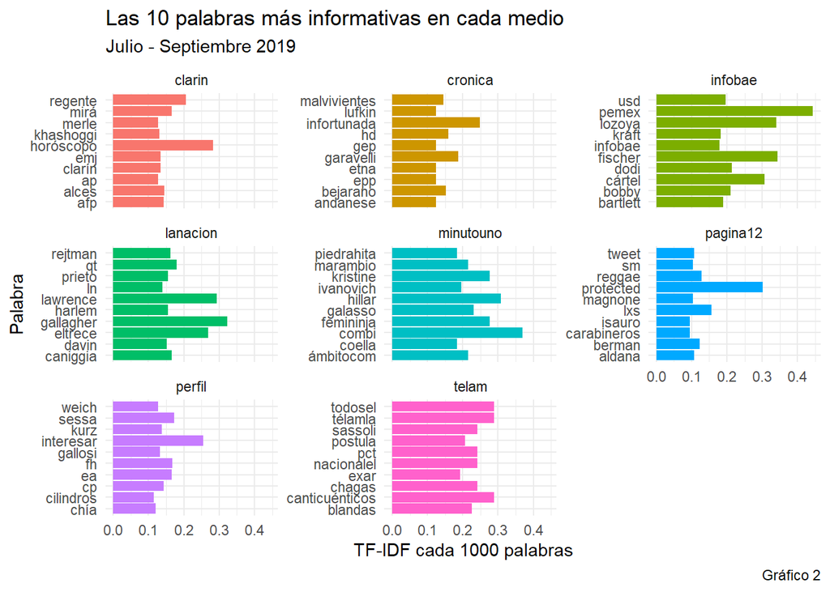

```r
ggplot(top_words_tf_idf, aes(x = tf_idf *1000,
                             y = word,
                             fill = medio)) +
  geom_col() +
  scale_fill_discrete(name = "Medio") +
  labs(x = "TF-IDF cada 1000 palabras",
       y = "Palabra") +
  facet_wrap(~medio, scales = "free_y") +
  theme_minimal()+
  theme(legend.position = "none") +
  labs(title = "Las 10 palabras más informativas en cada medio",
       subtitle = "Julio - Septiembre 2019",
       caption = "Gráfico 2" )
```

#### Gráfico 3: Las 3 palabras más utilizadas en los medios

[figure not shown]

```r
 top_words_tf_ok <- corpus_tf_idf_medio %>%
  group_by(medio) %>%
  slice_max(n = 3,
            order_by = tf,
            with_ties = FALSE) %>%
  ungroup()

ggplot(top_words_tf_ok, aes(x = tf*1000,
                             y = word,
                             fill = medio)) +
  geom_col() +
  scale_fill_discrete(name = "Medio") +
  labs(x = "TF-IDF cada 1000 palabras",
       y = "Palabra") +
  facet_wrap(~medio, scales = "free_y") +
  theme_minimal()+
  theme(legend.position = "none") +
  labs(title = "Las 3 palabras más informativas en cada medio",
       subtitle = "Julio - Septiembre 2019",
       caption = "Gráfico 3" )
```

```r
# Elimina objetos que ya no necesitamos
rm(top_words_tf, top_words_idf, top_words_tf_idf, corpus_tf_idf_medio,top_words_tf_ok, noticias_vacias, noticias_mal_descargadas, noticias_cortas, noticias_error_ln)
```

# Punto 2

```
- a) ¿Cuáles son los tópicos principales en el corpus?
- b) ¿Pueden evidenciar diferencias en cada uno de los medios? Explicar qué método se utilizó para responder la pregunta y cuáles son los supuestos del mismo
- c) Generar las visualizaciones más adecuadas para responder a las preguntas
```

## Trabajo con modelo Latent Dirichlet Allocation (LDA)

```r
# Creamos un corpus, pero esta vez centrados en los títulos
corpus_tf_idf_noticia <- corpus_noticias |>
  count(titulo, word,
        sort = TRUE) |>
  bind_tf_idf(term = word,
              # Al poner como "document" el titulo, el idf expresa cuánto usa más un titulo que otro
              # ciertas palabras
              document = titulo,
              n = n)

corpus_tf_idf_noticia |>
  slice_max(n = 500,
            order_by = tf_idf,
            # En caso de empates ("tie"), por default la función trae ambos valores; lo seteamos
            # para que sólo traiga uno
            with_ties = FALSE) |>
  print()
```

```
## # A tibble: 500 × 6
##    titulo                                        word      n     tf   idf tf_idf
##    <chr>                                         <chr> <int>  <dbl> <dbl>  <dbl>
##  1 La ONG Transparencia Internacional criticó a… tweet    14 0.165   4.90  0.807
##  2 ¿Se puede circular sin cédula azul?           cédu…    13 0.105   6.88  0.722
##  3 Donald Trump echó a su secretaria por hablar… west…     5 0.0769  8.83  0.679
##  4 Descubren un tejido que protege de las picad… graf…     8 0.0721  8.83  0.636
##  5 Paro de subtes: este jueves no habrá servici… bole…     5 0.0893  7.04  0.628
##  6 Ola de frío: cómo sigue el clima este jueves… nubl…     4 0.0976  6.27  0.611
##  7 Emoción en Hockenheim: Mick Schumacher dio u… schu…     5 0.0862  7.04  0.607
##  8 Nuevo Director de Syngenta Semillas           syng…     7 0.0745  8.14  0.606
##  9 Todo lo que hay que saber sobre La noche de … pizz…    12 0.0805  7.22  0.582
## 10 Un ranking de ovnis | Estados Unidos          avis…     5 0.0714  8.14  0.581
## # ℹ 490 more rows
```

### Document Term Matrix (DTM) del corpus de noticias

```r
# Creación de la Document Term Matrix (DTM) del corpus de noticias
corpus_dtm <- corpus_tf_idf_noticia %>%
  cast_dtm(term = word,
           document = titulo,
           value = n)

# La cantidad de documentos y de palabras parece coincidir con la del corpus
corpus_dtm |>
  print()
```

```
## <<DocumentTermMatrix (documents: 6841, terms: 105360)>>
## Non-/sparse entries: 1315660/719452100
## Sparsity           : 100%
## Maximal term length: 106
## Weighting          : term frequency (tf)
```

Ejecutamos el LDA con 7 tópicos

```r
# Como se saltea el paso anterior, se carga el modelo que ya está guardado en la carpeta de "models"

modelo_armado <- read_rds('models/LDA7.rds')
```

```r
                  # Si esta línea tira algún error, hagan install.packages("reshape2")
palabras_topicos <- tidy(modelo_armado, matrix = "beta")
#Lo pasamos a porcentajes
palabras_topicos %>%
  mutate(beta = round(100*beta, 6))
```

| topic | term | beta |
| --- | --- | --- |
| 1 | mujeres | 0.165088 |
| 2 | mujeres | 0.142552 |
| 3 | mujeres | 0.032827 |
| 4 | mujeres | 0.185225 |
| 5 | mujeres | 0.065423 |
| 6 | mujeres | 0.008203 |
| 7 | mujeres | 0.005288 |
| 1 | diputados | 0.000000 |
| 2 | diputados | 0.027998 |
| 3 | diputados | 0.000000 |

[output cut: 9990 more lines]

### Gráfico 4: Principales palabras por tópico en LDA

Visualizamos las principales palabras por tópico en LDA

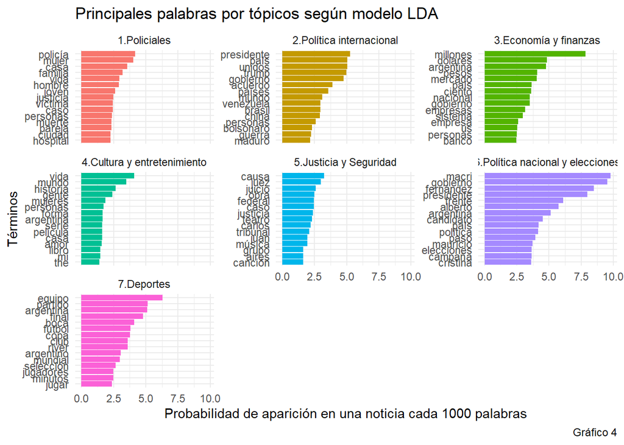

```r
# Agrupamos por tópicos y seleccionamos las principales 15 palabras de cada uno

top_palabras_topicos <- palabras_topicos %>%
  group_by(topic) %>%
  slice_max(beta, n = 15) %>%
  ungroup() %>%
  arrange(topic, -beta) %>%
  select(topic, term, beta) %>%
  mutate(topic = case_when(
    topic == 1 ~ "1.Policiales",
    topic == 2 ~ "2.Política internacional",
    topic == 3 ~ "3.Economía y finanzas",
    topic == 4 ~ "4.Cultura y entretenimiento",
    topic == 5 ~ "5.Justicia y Seguridad",
    topic == 6 ~ "6.Política nacional y elecciones",
    topic == 7 ~ "7.Deportes",
    TRUE ~ as.character(topic)
  ))

grafico4 <- top_palabras_topicos %>%
  mutate(term = reorder_within(term, beta, topic)) %>%
  ggplot(aes(x = beta * 1000,
             y = term,
             fill = factor(topic))) +
  geom_col(show.legend = FALSE) +
  facet_wrap(~ topic, scales='free_y') +
  scale_y_reordered() +
  labs(x = "Probabilidad de aparición en una noticia cada 1000 palabras",
       y = "Términos") +
  theme_minimal() +
  labs(title = "Principales palabras por tópicos según modelo LDA",
       caption = "Gráfico 4",
       plot.title = element_text(size = 10))

print (grafico4)
```

```r
# Guardamos el gráfico en la carpeta "Graficos"
ggsave(filename = "Graficos/Grafico4.png", plot = grafico4, width = 8, height = 6)
```

```r
# El gamma es el valor de probabilidad de cada noticia de pertenecer a cierto tópico
topicos_noticias <- tidy(modelo_armado, matrix = "gamma")
```

```r
# Obtener los datos de los tópicos por medio
topicos_por_medio <- topicos_noticias %>%
  rename(titulo = document) %>%
  left_join(noticias %>% select(titulo, medio) %>% unique()) %>%
  group_by(medio, topic) %>%
  summarise(mean = mean(gamma) * 100)
```

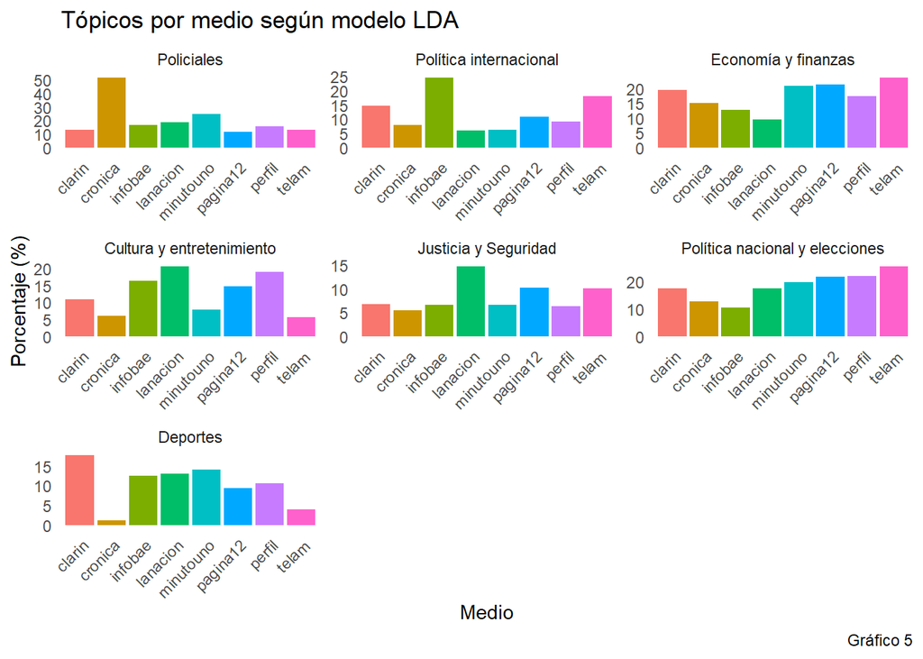

```r
# Renombrar las etiquetas de los tópicos
nombres_topicos <- c("1.Policiales" = "Policiales",
                     "2.Política internacional" = "Política internacional",
                     "3.Economía y finanzas" = "Economía y finanzas",
                     "4.Cultura y entretenimiento" = "Cultura y entretenimiento",
                     "5.Justicia y Seguridad" = "Justicia y Seguridad",
                     "6.Política nacional y elecciones" = "Política nacional y elecciones",
                     "7.Deportes" = "Deportes")

# Crear el gráfico facetado por tópico

grafico5 <- ggplot(topicos_por_medio, aes(x = factor(medio), y = mean)) +
  geom_col(aes(fill = medio), position = "dodge") +
  facet_wrap(~ factor(topic, labels = nombres_topicos), scales = "free") +
  theme_minimal() +
  theme(legend.position = "none",
        axis.text.x = element_text(angle = 45, hjust = 1),
        panel.border = element_blank(),
        panel.grid.major = element_blank(),
        panel.grid.minor = element_blank(),
        panel.background = element_blank()) +
  labs(x = "Medio",
       y = "Porcentaje (%)",
       title = "Tópicos por medio según modelo LDA",
       caption = "Gráfico 5")

print(grafico5)
```

```r
ggsave(filename = "Graficos/Grafico5.png", plot = grafico5, width = 8, height = 6)
```

### Tópicos resultantes LDA

Tópico 1: Policiales Tópico 2: Política internacional Tópico 3: Economía y finanzas Tópico 4: Cultura y entretenimiento Tópico 5: Justicia y Seguridad Tópico 6: Política nacional y elecciones Tópico 7: Deportes

## Alternativa con Structural Topic Modeling (STM)

Todos estos chunks están configurados para que no corran cuando se corre todo el código. Sin embargo, dan como resultado tópicos similares a los que se logra con LDA.

Construimos una DFM

```r
word_counts <- corpus_noticias %>%
        group_by(id,word) %>%
        summarise(n = n()) %>%
        ungroup()
```

[output not shown]

```r
noticias_dfm <- word_counts %>%
                cast_dfm(id, word, n)

noticias_dfm
```

```
## Document-feature matrix of: 6,874 documents, 105,360 features (99.82% sparse) and 0 docvars.
##     features
## docs abrir abrirse acceso aceptará aclaran acm acomodamiento acreedores actitud
##   8      1       1      1        1       1   1             1          2       2
##   30     0       0      0        0       0   0             0          0       0
##   31     0       0      0        0       0   0             0          0       0
##   40     0       0      0        0       0   0             0          0       0
##   43     0       0      0        0       0   0             0          0       0
##   66     0       0      0        0       0   0             0          0       0
##     features
## docs actividad
##   8          1
##   30         0
##   31         0
##   40         0
##   43         0
##   66         0
## [ reached max_ndoc ... 6,868 more documents, reached max_nfeat ... 105,350 more features ]
```

Entrenamos el DFM y establecemos la misma cantidad de tópicos que con LDA: 7 tópicos

```r
metadata <- corpus_noticias %>%
        group_by(id,medio ) %>%
        summarise(n = n()) %>%
        ungroup()
```

[output not shown]

```r
stm_7 <- read_rds('models/stm_7_prev_cont.rds')
```

Generamos la matriz beta y theta

```r
betas_stm <- tidy(stm_7, matrix = 'beta')
tetha_stm <- tidy(stm_7, matrix = 'theta')
```

### Gráfico 6: Principales palabras por tópico en STM

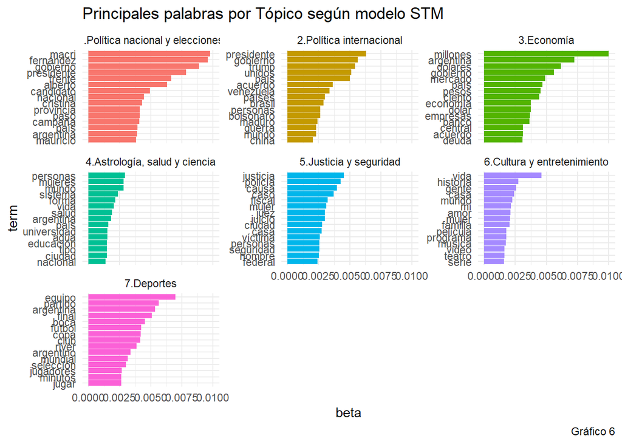

```r
grafico6 <- betas_stm %>%
  group_by(topic) %>%
  slice_max(beta, n = 15) %>%
  ungroup() %>%
  arrange(topic, -beta) %>%
  mutate(term = reorder_within(term, beta, topic),
         topic = case_when(
           topic == 1 ~ "1.Política nacional y elecciones",
           topic == 2 ~ "2.Política internacional",
           topic == 3 ~ "3.Economía",
           topic == 4 ~ "4.Astrología, salud y ciencia",
           topic == 5 ~ "5.Justicia y seguridad",
           topic == 6 ~ "6.Cultura y entretenimiento",
           topic == 7 ~ "7.Deportes",
           TRUE ~ as.character(topic))) %>%
  ggplot(aes(beta, term, fill = factor(topic))) +
  geom_col(show.legend = FALSE) +
  facet_wrap(~ topic, scales='free_y') +
  scale_y_reordered() +
  theme_minimal() +
  labs(title = "Principales palabras por Tópico según modelo STM",
       caption = "Gráfico 6",
       plot.title = element_text(size = 10))

  print(grafico6)
```

```r
# Guardar el gráfico como un archivo
ggsave(filename = "Graficos/Grafico6.png",
       plot = grafico6,
       width = 8, height = 6)
```

```r
theta_stm_7 <- tetha_stm %>%
  rename(id = document) %>%
  left_join(metadata)
```

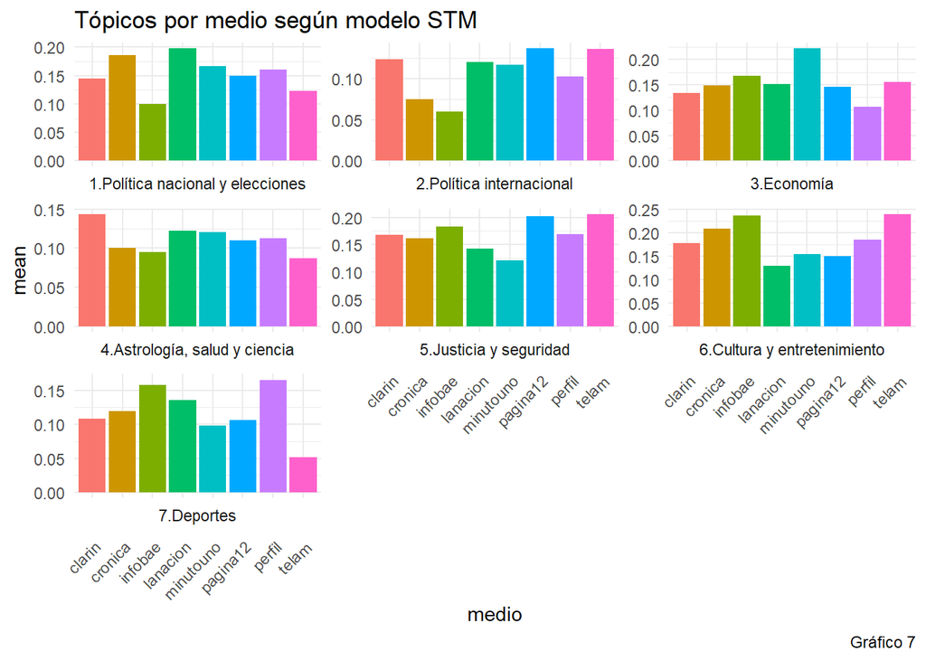

```r
grafico7 <- theta_stm_7 %>%
  group_by(medio, topic) %>%
  summarise(mean = mean(gamma)) %>%
  drop_na() %>%
  ggplot(aes(x=medio, y=mean, fill=medio)) +
    geom_col(position='dodge') +
    facet_wrap(~case_when(
           topic == 1 ~ "1.Política nacional y elecciones",
           topic == 2 ~ "2.Política internacional",
           topic == 3 ~ "3.Economía",
           topic == 4 ~ "4.Astrología, salud y ciencia",
           topic == 5 ~ "5.Justicia y seguridad",
           topic == 6 ~ "6.Cultura y entretenimiento",
           topic == 7 ~ "7.Deportes",
           TRUE ~ as.character(topic)), scales = "free_y", strip.position = "bottom")+     theme_minimal() +
    theme(legend.position = "none",  # Quitar la leyenda de medio
          axis.text.x = element_text(angle = 45, hjust = 1)) +  # Ajustar las etiquetas del eje x
    labs(title = "Tópicos por medio según modelo STM",
       caption = "Gráfico 7",
         plot.title = element_text(size = 14))
print(grafico7)
```

```r
ggsave(filename = "Graficos/Grafico7.png",
       plot = grafico7,
       width = 8, height = 6)
```

### Tópicos resultantes

```
- Tópico 1: Política nacional y elecciones
- Tópico 2: Política internacional
- Tópico 3: Economía y finanzas
- Tópico 4: Astrología, salud y ciencia
- Tópico 5: Justicia y seguridad
- Tópico 6: Cultura y entretenimiento
- Tópico 7: Deportes
```

# Punto 3

A continuación, seleccionar las noticias vinculadas a algún tópico relevante (por ejemplo, “Elecciones”) y construir un clasificador para predecir la orientación del diario. Utilizar alguno de los modelos de clasificación vistos a lo largo de al Diplomatura (regresión logística, random forest, etc.). Utilizar como features el “Spanish Billion Word Corpus and Embeddings”, analizado en clase. ¿Qué resultados arroja el modelo? ¿Es posible mediante el texto de las noticias conocer la línea editorial del diario? Generar las visualizaciones y tablas correspondientes para una correcta evaluación del modelo.

## Armado del corpus

Selección de noticias del tópico 6 política/elecciones del modelo LDA

```r
# Creamos el objeto con las noticias que más probablemente (70% de probabilidad) pertenecen al tópico 6, que es el que trata sobre política/ elecciones

noticias_topico_6 <- topicos_noticias |>
  mutate(gamma = round(gamma, 6)) |>
  filter(topic == 6,
         gamma > 0.7)
```

## Elimina objetos previos

```r
# Elimina todos los objetos excepto los necesarios para la consigna 3

# Lista todos los objetos que existen
todos_los_objetos <- ls()

# Sólo estos son necesarios para la consigna 3
objetos_a_no_eliminar <- c("noticias_topico_6", "noticias")

# Hace la diferencia
objetos_a_eliminar <- setdiff(todos_los_objetos, objetos_a_no_eliminar)

# Elimina los objetos
rm(list = objetos_a_eliminar)

rm("objetos_a_eliminar", "objetos_a_no_eliminar", "todos_los_objetos")
```

## Carga del embedding

Vamos a usar un embedding para predecir la orientación en función del texto de la noticia. En particular, el mismo está entrenado mediante el algoritmo wor2vec por C. Cardelino. Está entrenado sobre un corpus grande en español. Disponible en https://crscardellino.ar/SBWCE/ Primero escribirmos la función que carga el embedding y después la ejecutamos:

```r
load_embeddings <- function(path=NULL, type=c("w2v", "ft")){
        if (type=="w2v"){
                embedding <- word2vec::read.wordvectors(path,
                                                        type = "bin",
                                                        normalize = TRUE) %>%
                        as_tibble(rownames="word")
        }
        else if (type=="ft"){
                model <- fastTextR::ft_load(path)
                words <- fastTextR::ft_words(model)
                embedding <- fastTextR::ft_word_vectors(model,
                                                        words) %>%
                        as_tibble(rownames="word")
        }

        return(embedding)
}


embedding <- load_embeddings(path = "embedding/SBW-vectors-300-min5.bin/sbw_vectors.bin",
                             type = "w2v")
```

Vamos a realizar distintas pruebas con dos modelos de clasificación (Random Forest y Regresión logística regularizada por LASSO), realizando combinaciones de variables e hiperparámétros.

# PRUEBA 1 RANDOM FOREST

[output not shown]

## Sobre el corpus

### Tokenización y construcción de features mediante el embedding

```r
# Se arma el objeto "corpus_noticias_t6", con el conjunto de noticias que más probablemente pertenezcan al tópico 6 (política/elecciones), a lo cual se suman el texto y la orientación del medio de la noticia.

corpus_noticias_t6 <- noticias_topico_6 |>
  rename(titulo = document) |>
  left_join(noticias) |>
  select(titulo, gamma, id,
         #medio,
         orientacion, texto) |>
  mutate(orientacion = gsub("\\+ ", "", orientacion)) |>
  filter(orientacion != "neutro") |>
  mutate(orientacion = factor(orientacion,
                              levels = c("conservador", "progresista")))
table(corpus_noticias_t6$orientacion)
```

```
##
## conservador progresista
##         354         202
```

Tokenización pero sin pasar todo a minúscula y sin eliminar la puntuación.

```r
## No vamos a pasar a minúscula  y tampoco vamos a eliminar caracteres no ASCII para que se unan correctamente con el embedding

corpus_noticias_t6 <- corpus_noticias_t6 |>

        mutate(texto = str_replace_all(texto, "'\\[.*?¿\\]\\%'", " ")) |>
        # Reemplaza cualquier dígito por la cadena "DIGITO"
        mutate(texto = str_replace_all(texto, "[[:digit:]]+", "DIGITO"))
```

```r
corpus_noticias_t6 <- corpus_noticias_t6 |>
  mutate(title_id = row_number()) |>
  # No pasamos a minúscula ni eliminamos la puntuación para que se unan correctamente con el embedding
  unnest_tokens(word, texto,
                to_lower = FALSE,
                strip_punct = FALSE)
```

### Embedding: de palabra a noticia

```r
# Unimos las noticias con el embedding, para que cada palabra de este conjunto de noticias tenga las 300 dimensiones
corpus_c_embedding <- corpus_noticias_t6 |>
        left_join(embedding) |>
        drop_na()
```

Agrupamos por cada noticia y calculamos el promedio para cada dimensión de cada palabra que forma parte de una noticia. Se agrupa por cada noticia (que tiene un diario específico con una orientación específica) y calcula el promedio para cada dimensión de cada palabra que forma parte de una noticia. De esta forma, tenemos el valor promedio en cada dimensión de la noticia en su conjunto.

```r
noticias_c_embedding <- corpus_c_embedding %>%
  group_by(title_id, orientacion) %>%
  summarise(across(V1:V300, ~mean(.x, na.rm=TRUE))) %>%
  ungroup()
```

## Preparación del modelado

### Partición de los datos en entrenamiento (train) y prueba (test)

```r
set.seed(1234)

noticias_split <- initial_split(noticias_c_embedding,
                                strata = orientacion)

train_embed <- training(noticias_split)
test_embed <- testing(noticias_split)


table(train_embed$orientacion)
```

```
##
## conservador progresista
##         265         151
```

### Elaboración de la receta

```r
# Especificación de la receta
receta <- train_embed |>
  recipe(orientacion ~ .) |>
  update_role("title_id", new_role = "id")
  # No balanceamos
  #step_downsample(orientacion, under_ratio = 1)

# Se agrega al workflow
wf <- workflow() %>%
  add_recipe(receta)
```

### Tuneo

Los hiperparámetros a definir son: -`trees`: define el número de árboles que se van a establecer -`mtry`: cantidad de variables que se van a probar en cada iteración -`min_n`: mínima cantidad de observaciones que tiene que haber en cada nodo

```r
# Se establece el modelo a tunear
modelo_a_tunear <- rand_forest(trees = 1000,
                               mtry = tune(),
                               min_n = tune()) %>%
  set_mode("classification") %>%
  set_engine("ranger")

# Se agrega al workflow
wf <- wf |>
  add_model(modelo_a_tunear)
```

```r
set.seed(1234)

# Cross validation
embed_folds <- vfold_cv(train_embed, v = 5)
```

```r
a_tunear_1 <- read_rds('models/a_tunear_1.rds')
```

## Métricas y elección de hiperparámetros

```r
# Muestra las métricas en una tibble
a_tunear_1 |>
  collect_metrics() |>
  print()
```

```
## # A tibble: 120 × 8
##     mtry min_n .metric   .estimator  mean     n std_err .config
##    <int> <int> <chr>     <chr>      <dbl> <int>   <dbl> <chr>
##  1   234    10 f_meas    binary     0.774     5  0.0227 Preprocessor1_Model01
##  2   234    10 precision binary     0.723     5  0.0344 Preprocessor1_Model01
##  3   234    10 recall    binary     0.838     5  0.0249 Preprocessor1_Model01
##  4   234    10 roc_auc   binary     0.748     5  0.0233 Preprocessor1_Model01
##  5   195     5 f_meas    binary     0.780     5  0.0208 Preprocessor1_Model02
##  6   195     5 precision binary     0.726     5  0.0314 Preprocessor1_Model02
##  7   195     5 recall    binary     0.845     5  0.0154 Preprocessor1_Model02
##  8   195     5 roc_auc   binary     0.749     5  0.0240 Preprocessor1_Model02
##  9   148    24 f_meas    binary     0.773     5  0.0182 Preprocessor1_Model03
## 10   148    24 precision binary     0.723     5  0.0328 Preprocessor1_Model03
## # ℹ 110 more rows
```

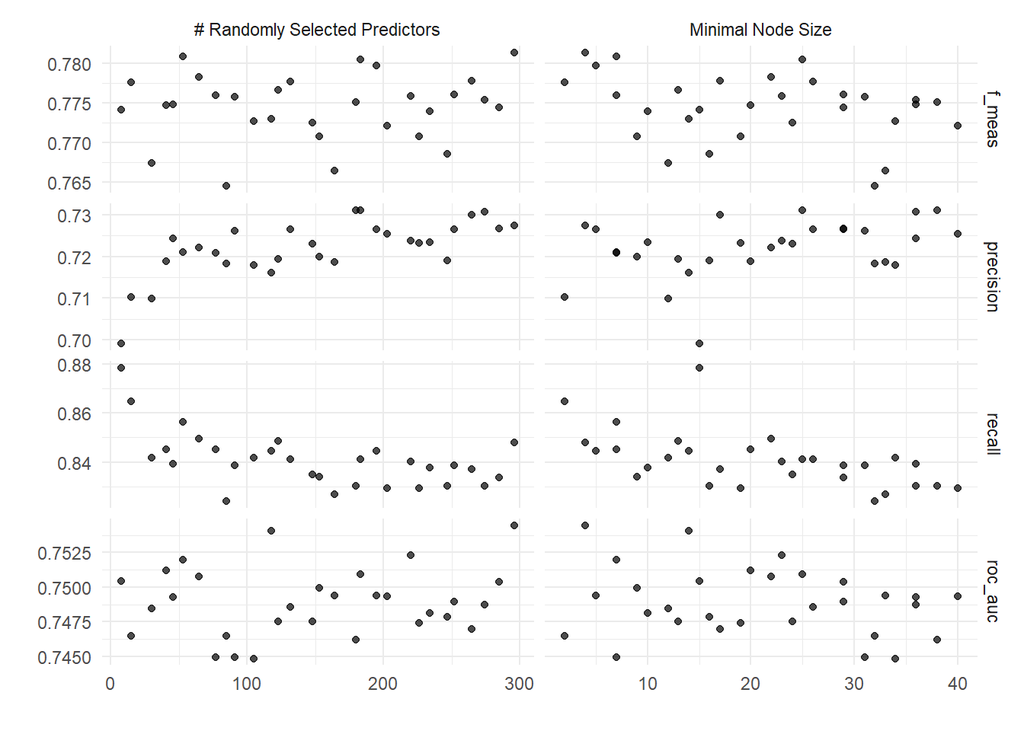

```r
a_tunear_1 |>
  autoplot() +
  theme_minimal()
```

```r
# Se muestran los hiperparámetros que dan la mejor curva ROC
show_best(a_tunear_1, "roc_auc")
```

| mtry | min_n | .metric | .estimator | mean | n | std_err | .config |
| --- | --- | --- | --- | --- | --- | --- | --- |
| 296 | 4 | roc_auc | binary | 0.7544600 | 5 | 0.02280499 | Preprocessor1_Model15 |
| 118 | 14 | roc_auc | binary | 0.7540619 | 5 | 0.02058586 | Preprocessor1_Model05 |
| 220 | 23 | roc_auc | binary | 0.7522890 | 5 | 0.02352678 | Preprocessor1_Model28 |
| 53 | 7 | roc_auc | binary | 0.7519610 | 5 | 0.01870273 | Preprocessor1_Model04 |
| 41 | 20 | roc_auc | binary | 0.7511894 | 5 | 0.02257884 | Preprocessor1_Model27 |

Si bien no se muestra aquí, probamos con otros parámetros posibles por si los hiperparámetros pudiesen generar un problema de overfitting. Pero en el set de test, la mejor curva ROC corresponde simultáneamente a los hiperparámetros que producen la mejor curva ROC en el set de train.

```r
#best_ROC <- show_best(a_tunear_1, "roc_auc") |>
#  filter(mtry == 118 &
#         min_n == 14)

best_ROC <- select_best(a_tunear_1,
                        "roc_auc")


# Finalizamos el modelo con los hiperparámetros que dan la mejor curva ROC
final_rf <- finalize_model(modelo_a_tunear,
                           best_ROC)

# Modelo final
final_rf
```

```
## Random Forest Model Specification (classification)
##
## Main Arguments:
##   mtry = 296
##   trees = 1000
##   min_n = 4
##
## Computational engine: ranger
```

## Entrenamiento del modelo final

```r
# Actualizamos al modelo final
fit_final <- wf |>
  update_model(final_rf) |>
  # Fiteamos a los datos de entrenamiento
  fit(train_embed)
```

## Evaluación sobre test

```r
# Creamos un nuevo flujo de trabajo, agregamos la receta y el modelo y ajustamos a los datos de entrenamiento
tree_fit <- workflow() %>%
  add_recipe(receta) %>%
  add_model(final_rf) %>%
  fit(data = train_embed)
```

```r
preds_embed <- test_embed %>%
        select(orientacion) %>%
        bind_cols(predict(tree_fit, test_embed, type="prob")) %>%
        bind_cols(predict(tree_fit, test_embed, type="class"))


print(preds_embed)
```

```
## # A tibble: 140 × 4
##    orientacion .pred_conservador .pred_progresista .pred_class
##    <fct>                   <dbl>             <dbl> <fct>
##  1 conservador             0.779            0.221  conservador
##  2 progresista             0.103            0.897  progresista
##  3 conservador             0.41             0.59   progresista
##  4 progresista             0.704            0.296  conservador
##  5 conservador             0.980            0.0205 conservador
##  6 conservador             0.408            0.592  progresista
##  7 progresista             0.780            0.220  conservador
##  8 conservador             0.600            0.400  conservador
##  9 progresista             0.487            0.513  progresista
## 10 conservador             0.718            0.282  conservador
## # ℹ 130 more rows
```

```r
metricas_1 <- roc_auc(preds_embed, orientacion, .pred_conservador) %>%
  bind_rows(accuracy(preds_embed, orientacion, .pred_class)) %>%
  bind_rows(precision(preds_embed, orientacion, .pred_class)) %>%
  bind_rows(recall(preds_embed, orientacion, .pred_class)) %>%
  bind_rows(f_meas(preds_embed, orientacion, .pred_class)) |>
  mutate(modelo = "modelo_1")

metricas_1
```

| .metric | .estimator | .estimate | modelo |
| --- | --- | --- | --- |
| roc_auc | binary | 0.6618198 | modelo_1 |
| accuracy | binary | 0.6500000 | modelo_1 |
| precision | binary | 0.7083333 | modelo_1 |
| recall | binary | 0.7640449 | modelo_1 |
| f_meas | binary | 0.7351351 | modelo_1 |

## Elimina objetos previos

```r
# Elimina todos los objetos excepto los necesarios para el siguiente modelo

# Lista todos los objetos que existen
todos_los_objetos <- ls()

# Sólo estos son necesarios para la consigna 3
objetos_a_no_eliminar <- c("noticias_topico_6", "noticias", "embedding", "metricas_1")

# Hace la diferencia
objetos_a_eliminar <- setdiff(todos_los_objetos, objetos_a_no_eliminar)

# Elimina los objetos
rm(list = objetos_a_eliminar)

rm("objetos_a_eliminar", "objetos_a_no_eliminar", "todos_los_objetos")
```

# PRUEBA 2 RANDOM FOREST

[output not shown]

## Sobre el corpus

### Tokenización y construcción de features mediante el embedding

```r
# Se arma el objeto "corpus_noticias_t6", que con el conjunto de noticias que más probablemente pertenezcan al tópico 6 (política/ elecciones), a lo cual se suman el texto, el medio y la orientación del medio del cual sale la noticia

corpus_noticias_t6 <- noticias_topico_6 |>
  rename(titulo = document) |>
  left_join(noticias) |>
  select(titulo, gamma, id,
         medio,
         orientacion, texto) |>
  mutate(orientacion = gsub("\\+ ", "", orientacion)) |>
  filter(orientacion != "neutro")|>
  mutate(orientacion = factor(orientacion,
                              levels = c("conservador", "progresista")))
table(corpus_noticias_t6$medio)
```

```
##
##    clarin   infobae  lanacion minutouno  pagina12
##       196        46       112        60       142
```

Tokenización pero sin pasar todo a minúscula y sin eliminar la puntuación

```r
## No vamos a pasar a minúscula nada y tampoco vamos a eliminar caracteres no ascii para que se unan correctamente con el embedding

corpus_noticias_t6 <- corpus_noticias_t6 |>
        mutate(texto = str_replace_all(texto, "'\\[.*?¿\\]\\%'", " ")) |>
        # Reemplaza cualquier dígito por la cadena "DIGITO"
        mutate(texto = str_replace_all(texto, "[[:digit:]]+", "DIGITO"))
```

```r
corpus_noticias_t6 <- corpus_noticias_t6 |>
  mutate(title_id = row_number()) |>
  # No pasamos a minúscula ni eliminamos la puntuación para que se unan correctamente con el embedding
  unnest_tokens(word, texto,
                to_lower = FALSE,
                strip_punct = FALSE)
```

### Embedding: de palabra a noticia

```r
# Unimos las noticias con el embedding, para que cada palabra de este conjunto de noticias tenga las 300 dimensiones
corpus_c_embedding <- corpus_noticias_t6 |>
        left_join(embedding) |>
        drop_na()
```

Agrupamos por cada noticia y calculamos el promedio para cada dimensión de cada palabra que forma parte de una noticia. Se agrupa por cada noticia (que tiene un diario específico, con una orientación específica) y calcula el promedio para cada dimensión de cada palabra que forma parte de una noticia. De esta forma, tenemos el valor promedio en cada dimensión de la noticia en su conjunto.

```r
noticias_c_embedding <- corpus_c_embedding %>%
  group_by(title_id, medio, orientacion) %>%
  summarise(across(V1:V300, ~mean(.x, na.rm=TRUE))) %>%
  ungroup()
```

## Preparación del modelado (Prueba 2)

### Partición de los datos en entrenamiento (train) y prueba (test)

```r
set.seed(1234)

noticias_split <- initial_split(noticias_c_embedding,
                                strata = medio)

train_embed <- training(noticias_split)
test_embed <- testing(noticias_split)


table(train_embed$medio)
```

```
##
##    clarin   infobae  lanacion minutouno  pagina12
##       145        35        83        44       108
```

### Elaboración de la receta

```r
# Especificación de la receta
receta <- train_embed |>
  recipe(orientacion ~ .) %>%
  step_rm(medio) |>
  update_role("title_id", new_role = "ID") %>%
  step_downsample(orientacion,
                  under_ratio = 1)


# Se agrega al workflow
wf <- workflow() %>%
  add_recipe(receta)
```

### Tuneo

Los hiperparámetros a definir son: -`trees`: define el número de árboles que se van a establecer -`mtry`: cantidad de variables que se van a probar en cada iteración -`min_n`: mínima cantidad de observaciones que tiene que haber en cada nodo

```r
# Establecimiento del modelo a tunear
modelo_a_tunear <- rand_forest(trees = 1000,
                               mtry = tune(),
                               min_n = tune()) %>%
  set_mode("classification") %>%
  set_engine("ranger")


# Se agrega al workflow
wf <- wf |>
  add_model(modelo_a_tunear)
```

```r
set.seed(1234)

# Cross validation
embed_folds <- vfold_cv(train_embed, v = 5)
```

```r
a_tunear_2 <- read_rds('models/a_tunear_2.rds')
```

## Métricas y elección de hiperparámetros

```r
# Muestra las métricas en una tibble
a_tunear_2 |>
  collect_metrics() |>
  print()
```

```
## # A tibble: 120 × 8
##     mtry min_n .metric   .estimator  mean     n std_err .config
##    <int> <int> <chr>     <chr>      <dbl> <int>   <dbl> <chr>
##  1   234    10 f_meas    binary     0.694     5  0.0132 Preprocessor1_Model01
##  2   234    10 precision binary     0.780     5  0.0297 Preprocessor1_Model01
##  3   234    10 recall    binary     0.630     5  0.0223 Preprocessor1_Model01
##  4   234    10 roc_auc   binary     0.727     5  0.0296 Preprocessor1_Model01
##  5   195     5 f_meas    binary     0.697     5  0.0149 Preprocessor1_Model02
##  6   195     5 precision binary     0.792     5  0.0332 Preprocessor1_Model02
##  7   195     5 recall    binary     0.625     5  0.0137 Preprocessor1_Model02
##  8   195     5 roc_auc   binary     0.727     5  0.0303 Preprocessor1_Model02
##  9   148    24 f_meas    binary     0.700     5  0.0122 Preprocessor1_Model03
## 10   148    24 precision binary     0.794     5  0.0332 Preprocessor1_Model03
## # ℹ 110 more rows
```

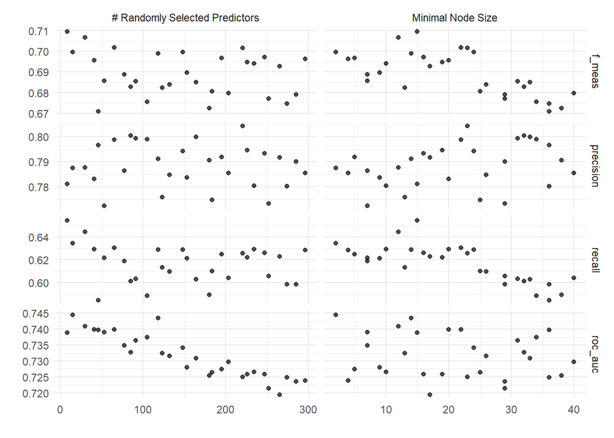

```r
a_tunear_2 |>
  autoplot() +
  theme_minimal()
```

```r
# Mostramos los hiperparámetros que dan la mejor curva ROC
show_best(a_tunear_2, "roc_auc")
```

| mtry | min_n | .metric | .estimator | mean | n | std_err | .config |
| --- | --- | --- | --- | --- | --- | --- | --- |
| 15 | 2 | roc_auc | binary | 0.7444554 | 5 | 0.02640132 | Preprocessor1_Model29 |
| 118 | 14 | roc_auc | binary | 0.7434337 | 5 | 0.03005968 | Preprocessor1_Model05 |
| 30 | 12 | roc_auc | binary | 0.7408493 | 5 | 0.02992640 | Preprocessor1_Model13 |
| 65 | 22 | roc_auc | binary | 0.7399163 | 5 | 0.03339757 | Preprocessor1_Model12 |
| 41 | 20 | roc_auc | binary | 0.7398852 | 5 | 0.02711095 | Preprocessor1_Model27 |

Si bien no se muestra, probamos con los otros parámetros posibles por si los hiperparámetros pudiesen generar un problema de overfitting. Pero en el set de test, la mejor curva ROC corresponde simultáneamente a los hiperparámetros que producen la mejor curva ROC en el set de train

```r
# best_ROC <- show_best(a_tunear_2, "roc_auc") |>
#  filter(mtry == 118 &
#         min_n == 14)

best_ROC <- select_best(a_tunear_2,
                        "roc_auc")


# Finalizamos el modelo con los hiperparámetros que dan la mejor curva ROC
final_rf <- finalize_model(modelo_a_tunear,
                           best_ROC)

# Modelo final
final_rf
```

```
## Random Forest Model Specification (classification)
##
## Main Arguments:
##   mtry = 15
##   trees = 1000
##   min_n = 2
##
## Computational engine: ranger
```

## Entrenamiento modelo final

```r
# Actualizamos al modelo final
fit_final <- wf |>
  update_model(final_rf) |>
  # Fiteamos a los datos de entrenamiento
  fit(train_embed)
```

## Evaluación sobre test

```r
# Crear un nuevo flujo de trabajo, agregar la receta y el modelo, y ajustar al conjunto de datos de entrenamiento en una sola línea
tree_fit <- workflow() %>%
  add_recipe(receta) %>%
  add_model(final_rf) %>%
  fit(data = train_embed)
```

```r
preds_embed <- test_embed %>%
        select(orientacion) %>%
        bind_cols(predict(tree_fit, test_embed, type="prob")) %>%
        bind_cols(predict(tree_fit, test_embed, type="class"))

print(preds_embed)
```

```
## # A tibble: 141 × 4
##    orientacion .pred_conservador .pred_progresista .pred_class
##    <fct>                   <dbl>             <dbl> <fct>
##  1 progresista             0.209             0.791 progresista
##  2 conservador             0.760             0.240 conservador
##  3 conservador             0.398             0.602 progresista
##  4 progresista             0.653             0.347 conservador
##  5 conservador             0.530             0.470 conservador
##  6 progresista             0.63              0.37  conservador
##  7 conservador             0.377             0.623 progresista
##  8 conservador             0.386             0.614 progresista
##  9 conservador             0.505             0.494 conservador
## 10 conservador             0.810             0.190 conservador
## # ℹ 131 more rows
```

```r
metricas_2 <- roc_auc(preds_embed, orientacion, .pred_conservador) %>%
  bind_rows(accuracy(preds_embed, orientacion, .pred_class)) %>%
  bind_rows(precision(preds_embed, orientacion, .pred_class)) %>%
  bind_rows(recall(preds_embed, orientacion, .pred_class)) %>%
  bind_rows(f_meas(preds_embed, orientacion, .pred_class)) |>
  mutate(modelo = "modelo_2")

metricas_2
```

| .metric | .estimator | .estimate | modelo |
| --- | --- | --- | --- |
| roc_auc | binary | 0.7442857 | modelo_2 |
| accuracy | binary | 0.7304965 | modelo_2 |
| precision | binary | 0.8271605 | modelo_2 |
| recall | binary | 0.7362637 | modelo_2 |
| f_meas | binary | 0.7790698 | modelo_2 |

## Elimina objetos previos

```r
# Elimina todos los objetos excepto los necesarios para el siguiente modelo

# Lista todos los objetos que existen
todos_los_objetos <- ls()

# Sólo estos son necesarios para la consigna 3
objetos_a_no_eliminar <- c("noticias_topico_6", "noticias", "embedding", "metricas_1", "metricas_2")

# Hace la diferencia
objetos_a_eliminar <- setdiff(todos_los_objetos, objetos_a_no_eliminar)

# Elimina los objetos
rm(list = objetos_a_eliminar)

rm("objetos_a_eliminar", "objetos_a_no_eliminar", "todos_los_objetos")
```

# PRUEBA 3 REGRESIÓN LOGÍSTICA LASSO:

[output not shown]

## Sobre el corpus

### Tokenización y construcción de features mediante el embedding

```r
# Se arma el objeto "corpus_noticias_t6", que con el conjunto de noticias que más probablemente pertenezcan al tópico 6 (política/ elecciones), a lo cual se suman el texto y la orientación del medio del cual sale la noticia

corpus_noticias_t6 <- noticias_topico_6 |>
  rename(titulo = document) |>
  left_join(noticias) |>
  select(titulo, gamma, id,
         #medio,
         orientacion, texto) |>
  mutate(orientacion = gsub("\\+ ", "", orientacion)) |>
  filter(orientacion != "neutro") |>
  mutate(orientacion = factor(orientacion,
                              levels = c("conservador", "progresista")))
                              #levels = c("conservador", "neutro", "progresista")))

table(corpus_noticias_t6$orientacion)
```

```
##
## conservador progresista
##         354         202
```

Tokenización pero sin pasar todo a minúscula y sin eliminar la puntuación.

```r
## No vamos a pasar a minúscula nada y tampoco vamos a eliminar caracteres no ASCII para que se unan correctamente con el embedding

corpus_noticias_t6 <- corpus_noticias_t6 %>%
        mutate(texto = str_replace_all(texto, "'\\[.*?¿\\]\\%'", " ")) %>%
        # Reemplaza cualquier dígito por la cadena "DIGITO"
        mutate(texto = str_replace_all(texto, "[[:digit:]]+", "DIGITO"))
```

```r
corpus_noticias_t6 <- corpus_noticias_t6 |>
  mutate(title_id = row_number()) |>
  # No pasamos a minúscula ni eliminamos la puntuación para que se unan correctamente con el embedding
  unnest_tokens(word, texto,
                to_lower = FALSE,
                strip_punct = FALSE)
```

### Embedding: de palabra a noticia

```r
# Unimos las noticias con el embedding, para que cada palabra de este conjunto de noticias tenga las 300 dimensiones
corpus_c_embedding <- corpus_noticias_t6 |>
        left_join(embedding) |>
        drop_na()
```

Agrupamos por cada noticia y calculamos el promedio para cada dimensión de cada palabra que forma parte de una noticia. Se agrupa por cada noticia (que tiene un diario específico, con una orientación específica) y calcula el promedio para cada dimensión de cada palabra que forma parte de una noticia. De esta forma, tenemos el valor promedio en cada dimensión de la noticia en su conjunto.

```r
noticias_c_embedding <- corpus_c_embedding %>%
  group_by(title_id, orientacion) %>%
  summarise(across(V1:V300, ~mean(.x, na.rm=TRUE))) %>%
  ungroup()
```

## Preparación del modelado (Prueba 3)

### Partición de los datos en entrenamiento (train) y prueba (test)

```r
set.seed(1234)

noticias_split <- initial_split(noticias_c_embedding,
                                strata = orientacion)

train_embed <- training(noticias_split)
test_embed <- testing(noticias_split)


table(train_embed$orientacion)
```

```
##
## conservador progresista
##         265         151
```

### Elaboración de la receta

```r
# Se específica la receta
receta_lasso <- train_embed |>
  recipe(orientacion ~ .) %>%
  update_role("title_id", new_role = "ID")
  #step_downsample(orientacion,
  #                under_ratio = 1)


# Se agrega al workflow
wf <- workflow() %>%
  add_recipe(receta_lasso)
```

### Tuneo

```r
# Establecimiento  del modelo a tunear
modelo_a_tunear <- logistic_reg(penalty = tune(),
                                mixture = 1) %>%
  set_mode("classification") %>%
  set_engine("glmnet")


# Se agrega al workflow
wf <- wf |>
  add_model(modelo_a_tunear)
```

```r
set.seed(1234)

# Cross validation
embed_folds <- vfold_cv(train_embed, v = 5)
```

```r
# Se especifica la grilla
grid_lasso <- grid_regular(penalty(),
                           levels = 30)
```

```r
a_tunear_3 <- read_rds('models/a_tunear_3.rds')
```

## Métricas y elección hiperparámetros

```r
# Muestra las métricas en una tibble
a_tunear_3 |>
  collect_metrics() |>
  print()
```

```
## # A tibble: 60 × 7
##     penalty .metric  .estimator  mean     n std_err .config
##       <dbl> <chr>    <chr>      <dbl> <int>   <dbl> <chr>
##  1 1   e-10 accuracy binary     0.676     5  0.0336 Preprocessor1_Model01
##  2 1   e-10 roc_auc  binary     0.693     5  0.0413 Preprocessor1_Model01
##  3 2.21e-10 accuracy binary     0.676     5  0.0336 Preprocessor1_Model02
##  4 2.21e-10 roc_auc  binary     0.693     5  0.0413 Preprocessor1_Model02
##  5 4.89e-10 accuracy binary     0.676     5  0.0336 Preprocessor1_Model03
##  6 4.89e-10 roc_auc  binary     0.693     5  0.0413 Preprocessor1_Model03
##  7 1.08e- 9 accuracy binary     0.676     5  0.0336 Preprocessor1_Model04
##  8 1.08e- 9 roc_auc  binary     0.693     5  0.0413 Preprocessor1_Model04
##  9 2.40e- 9 accuracy binary     0.676     5  0.0336 Preprocessor1_Model05
## 10 2.40e- 9 roc_auc  binary     0.693     5  0.0413 Preprocessor1_Model05
## # ℹ 50 more rows
```

```r
#a_tunear_3 |>
  #autoplot() +
  #theme_minimal()
```

```r
# Mostramos los hiperparámetros que dan la mejor curva ROC
show_best(a_tunear_3, "roc_auc")
```

| penalty | .metric | .estimator | mean | n | std_err | .config |
| --- | --- | --- | --- | --- | --- | --- |
| 8.531679e-03 | roc_auc | binary | 0.7066328 | 5 | 0.03259597 | Preprocessor1_Model24 |
| 1.887392e-02 | roc_auc | binary | 0.7006735 | 5 | 0.03539479 | Preprocessor1_Model25 |
| 4.175319e-02 | roc_auc | binary | 0.6969910 | 5 | 0.03560624 | Preprocessor1_Model26 |
| 3.856620e-03 | roc_auc | binary | 0.6935426 | 5 | 0.03704336 | Preprocessor1_Model23 |
| 1.487352e-05 | roc_auc | binary | 0.6929765 | 5 | 0.04132067 | Preprocessor1_Model16 |

Si bien no se muestra, seleccionamos el cuarto valor de penalty, ya que se obtiene, aplicando el modelo sobre el set de test, una curva ROC más alta.

```r
best_ROC <- show_best(a_tunear_3, "roc_auc") |>
  filter(.config == "Preprocessor1_Model23")

# best_ROC <- select_best(a_tunear_3,
#                        "roc_auc")


# Finalizamos el modelo con los hiperparámetros que dan la mejor curva ROC
final_lasso <- finalize_model(modelo_a_tunear,
                              best_ROC)

# Modelo final
final_lasso
```

```
## Logistic Regression Model Specification (classification)
##
## Main Arguments:
##   penalty = 0.00385662042116347
##   mixture = 1
##
## Computational engine: glmnet
```

## Entrenamiento modelo final

```r
# Actualizamos al modelo final
fit_final <- wf |>
  update_model(final_lasso) |>
  # Fiteamos a los datos de entrenamiento
  fit(train_embed)
```

## Evaluación sobre test

```r
# Crear un nuevo flujo de trabajo, agregar la receta y el modelo, y ajustar al conjunto de datos de entrenamiento en una sola línea
lasso_fit <- workflow() %>%
  add_recipe(receta_lasso) %>%
  add_model(final_lasso) %>%
  fit(data = train_embed)
```

```r
preds_embed <- test_embed %>%
        select(orientacion) %>%
        bind_cols(predict(lasso_fit, test_embed, type="prob")) %>%
        bind_cols(predict(lasso_fit, test_embed, type="class"))

print(preds_embed)
```

```
## # A tibble: 140 × 4
##    orientacion .pred_conservador .pred_progresista .pred_class
##    <fct>                   <dbl>             <dbl> <fct>
##  1 conservador           0.594            0.406    conservador
##  2 progresista           0.00105          0.999    progresista
##  3 conservador           0.122            0.878    progresista
##  4 progresista           0.487            0.513    progresista
##  5 conservador           0.985            0.0153   conservador
##  6 conservador           0.385            0.615    progresista
##  7 progresista           0.965            0.0354   conservador
##  8 conservador           0.557            0.443    conservador
##  9 progresista           0.0684           0.932    progresista
## 10 conservador           0.999            0.000970 conservador
## # ℹ 130 more rows
```

```r
# Calcular las métricas de evaluación
metricas_3 <- roc_auc(preds_embed, orientacion, .pred_conservador) %>%
  bind_rows(accuracy(preds_embed, orientacion, .pred_class)) %>%
  bind_rows(precision(preds_embed, orientacion, .pred_class)) %>%
  bind_rows(recall(preds_embed, orientacion, .pred_class)) %>%
  bind_rows(f_meas(preds_embed, orientacion, .pred_class)) |>
  mutate(modelo = "modelo_3")

metricas_3
```

| .metric | .estimator | .estimate | modelo |
| --- | --- | --- | --- |
| roc_auc | binary | 0.7005948 | modelo_3 |
| accuracy | binary | 0.6642857 | modelo_3 |
| precision | binary | 0.7333333 | modelo_3 |
| recall | binary | 0.7415730 | modelo_3 |
| f_meas | binary | 0.7374302 | modelo_3 |

## Elimina objetos previos

```r
# Elimina todos los objetos excepto los necesarios para el siguiente modelo

# Lista todos los objetos que existen
todos_los_objetos <- ls()

# Sólo estos son necesarios para la consigna 3
objetos_a_no_eliminar <- c("noticias_topico_6", "noticias", "embedding", "metricas_1", "metricas_2", "metricas_3")

# Hace la diferencia
objetos_a_eliminar <- setdiff(todos_los_objetos, objetos_a_no_eliminar)

# Elimina los objetos
rm(list = objetos_a_eliminar)

rm("objetos_a_eliminar", "objetos_a_no_eliminar", "todos_los_objetos")
```

# PRUEBA 4 RANDOM FOREST

[output not shown]

## Sobre el corpus

### Tokenización y construcción de features mediante el embedding

```r
# Se arma el objeto "corpus_noticias_t6", que con el conjunto de noticias que más probablemente pertenezcan al tópico 6 (política/ elecciones), a lo cual se suman el texto, el medio y la orientación del medio del cual sale la noticia

corpus_noticias_t6 <- noticias_topico_6 |>
  rename(titulo = document) |>
  left_join(noticias) |>
  select(titulo, gamma, id,
         medio,
         orientacion, texto) |>
  mutate(orientacion = gsub("\\+ ", "", orientacion)) |>
  # filter(orientacion != "neutro") |>
  mutate(orientacion = ifelse(orientacion %in% c('progresista', 'neutro'), 'no conservador', 'conservador')) |>
  mutate(orientacion = factor(orientacion,
                            levels = c("conservador", "no conservador")))
table(corpus_noticias_t6$orientacion)
```

```
##
##    conservador no conservador
##            354            568
```

Tokenización pero sin pasar todo a minúscula y sin eliminar la puntuación

```r
## No vamos a pasar a minúscula nada y tampoco vamos a eliminar caracteres no ascii para que se unan correctamente con el embedding

corpus_noticias_t6 <- corpus_noticias_t6 |>
        mutate(texto = str_replace_all(texto, "'\\[.*?¿\\]\\%'", " ")) |>
        # Reemplaza cualquier dígito por la cadena "DIGITO"
        mutate(texto = str_replace_all(texto, "[[:digit:]]+", "DIGITO"))
```

```r
corpus_noticias_t6 <- corpus_noticias_t6 |>
  mutate(title_id = row_number()) |>
  # No pasamos a minúscula ni eliminamos la puntuación para que se unan correctamente con el embedding
  unnest_tokens(word, texto,
                to_lower = FALSE,
                strip_punct = FALSE)
```

### Embedding: de palabra a noticia

```r
# Unimos las noticias con el embedding, para que cada palabra de este conjunto de noticias tenga las 300 dimensiones
corpus_c_embedding <- corpus_noticias_t6 |>
        left_join(embedding) |>
        drop_na()
```

Agrupamos por cada noticia y calculamos el promedio para cada dimensión de cada palabra que forma parte de una noticia. Se agrupa por cada noticia (que tiene un diario específico, con una orientación específica) y calcula el promedio para cada dimensión de cada palabra que forma parte de una noticia. De esta forma, tenemos el valor promedio en cada dimensión de la noticia en su conjunto.

```r
noticias_c_embedding <- corpus_c_embedding %>%
  group_by(title_id, medio, orientacion) %>%
  summarise(across(V1:V300, ~mean(.x, na.rm=TRUE))) %>%
  ungroup()
```

## Preparación del modelado (Prueba 4)

### Partición de los datos en entrenamiento (train) y prueba (test)

```r
set.seed(1234)

noticias_split <- initial_split(noticias_c_embedding,
                                strata = medio)

train_embed <- training(noticias_split)
test_embed <- testing(noticias_split)


table(train_embed$medio)
```

```
##
##    clarin   cronica   infobae  lanacion minutouno  pagina12    perfil     telam
##       149        40        34        87        39       109       183        49
```

### Elaboración de la receta

```r
# Se específica la receta
receta <- train_embed |>
  recipe(orientacion ~ .) %>%
  step_rm(medio) |>
  update_role("title_id", new_role = "ID") %>%
  step_downsample(orientacion,
                  under_ratio = 1)


# Se agrega al workflow
wf <- workflow() %>%
  add_recipe(receta)
```

### Tuneo

Los hiperparámetros a definir son: -`trees`: define el número de árboles que se van a establecer -`mtry`: cantidad de variables que se van a probar en cada iteración -`min_n`: mínima cantidad de observaciones que tiene que haber en cada nodo

```r
# Establezco el modelo a tunear
modelo_a_tunear <- rand_forest(trees = 1000,
                               mtry = tune(),
                               min_n = tune()) %>%
  set_mode("classification") %>%
  set_engine("ranger")


# Se agrega al workflow
wf <- wf |>
  add_model(modelo_a_tunear)
```

```r
set.seed(1234)

# Cross validation
embed_folds <- vfold_cv(train_embed, v = 5)
```

```r
a_tunear_4 <- read_rds('models/a_tunear_4.rds')
```

## Métricas y elección hiperparámetros

```r
# Muestra las métricas en una tibble
a_tunear_4 |>
  collect_metrics() |>
  print()
```

```
## # A tibble: 120 × 8
##     mtry min_n .metric   .estimator  mean     n std_err .config
##    <int> <int> <chr>     <chr>      <dbl> <int>   <dbl> <chr>
##  1    79     4 f_meas    binary     0.564     5  0.0242 Preprocessor1_Model01
##  2    79     4 precision binary     0.534     5  0.0149 Preprocessor1_Model01
##  3    79     4 recall    binary     0.600     5  0.0386 Preprocessor1_Model01
##  4    79     4 roc_auc   binary     0.661     5  0.0168 Preprocessor1_Model01
##  5     5    15 f_meas    binary     0.532     5  0.0350 Preprocessor1_Model02
##  6     5    15 precision binary     0.511     5  0.0204 Preprocessor1_Model02
##  7     5    15 recall    binary     0.562     5  0.0568 Preprocessor1_Model02
##  8     5    15 roc_auc   binary     0.660     5  0.0181 Preprocessor1_Model02
##  9   249    29 f_meas    binary     0.544     5  0.0254 Preprocessor1_Model03
## 10   249    29 precision binary     0.527     5  0.0135 Preprocessor1_Model03
## # ℹ 110 more rows
```

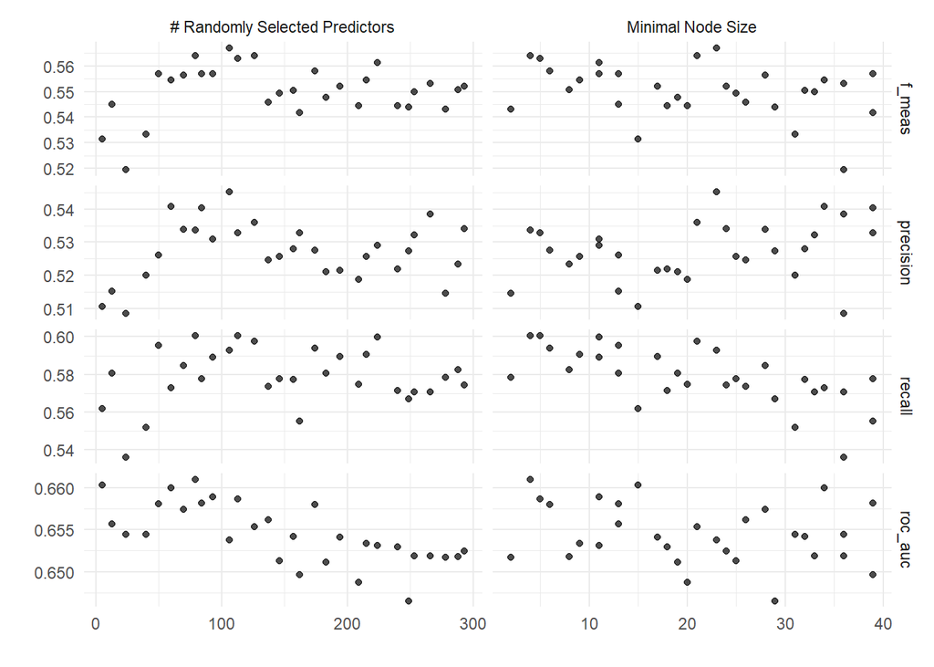

```r
a_tunear_4 |>
  autoplot() +
  theme_minimal()
```

```r
# Mostramos los hiperparámetros que dan la mejor curva ROC
show_best(a_tunear_4, "roc_auc")
```

| mtry | min_n | .metric | .estimator | mean | n | std_err | .config |
| --- | --- | --- | --- | --- | --- | --- | --- |
| 79 | 4 | roc_auc | binary | 0.6609971 | 5 | 0.01682359 | Preprocessor1_Model01 |
| 5 | 15 | roc_auc | binary | 0.6602962 | 5 | 0.01809781 | Preprocessor1_Model02 |
| 60 | 34 | roc_auc | binary | 0.6599567 | 5 | 0.01543645 | Preprocessor1_Model24 |
| 93 | 11 | roc_auc | binary | 0.6589333 | 5 | 0.01447567 | Preprocessor1_Model16 |
| 113 | 5 | roc_auc | binary | 0.6586500 | 5 | 0.01089655 | Preprocessor1_Model08 |

Si bien no se muestra, probamos con los otros parámetros posibles por si los hiperparámetros pudiesen generar un problema de overfitting. Pero en el set de test, la mejor curva ROC corresponde simultáneamente a los hiperparámetros que producen la mejor curva ROC en el set de train

```r
#best_ROC <- show_best(a_tunear_4, "roc_auc") |>
#  filter(mtry == 113 &
#         min_n == 5)

best_ROC <- select_best(a_tunear_4,
                        "roc_auc")


# Finalizamos el modelo con los hiperparámetros que dan la mejor curva ROC
final_rf <- finalize_model(modelo_a_tunear,
                           best_ROC)

# Modelo final
final_rf
```

```
## Random Forest Model Specification (classification)
##
## Main Arguments:
##   mtry = 79
##   trees = 1000
##   min_n = 4
##
## Computational engine: ranger
```

## Entrenamiento modelo final

```r
# Actualizamos al modelo final
fit_final <- wf |>
  update_model(final_rf) |>
  # Fiteamos a los datos de entrenamiento
  fit(train_embed)
```

## Evaluación sobre test

```r
# Crear un nuevo flujo de trabajo, agregar la receta y el modelo, y ajustar al conjunto de datos de entrenamiento en una sola línea
tree_fit <- workflow() %>%
  add_recipe(receta) %>%
  add_model(final_rf) %>%
  fit(data = train_embed)
```

```r
preds_embed <- test_embed %>%
        select(orientacion) %>%
        bind_cols(predict(tree_fit, test_embed, type="prob")) %>%
        bind_cols(predict(tree_fit, test_embed, type="class"))

print(preds_embed)
```

```
## # A tibble: 232 × 4
##    orientacion    .pred_conservador `.pred_no conservador` .pred_class
##    <fct>                      <dbl>                  <dbl> <fct>
##  1 no conservador             0.615                  0.385 conservador
##  2 conservador                0.369                  0.631 no conservador
##  3 no conservador             0.624                  0.376 conservador
##  4 conservador                0.403                  0.597 no conservador
##  5 conservador                0.540                  0.460 conservador
##  6 conservador                0.758                  0.241 conservador
##  7 conservador                0.549                  0.451 conservador
##  8 conservador                0.642                  0.358 conservador
##  9 no conservador             0.408                  0.592 no conservador
## 10 conservador                0.280                  0.720 no conservador
## # ℹ 222 more rows
```

```r
metricas_4 <- roc_auc(preds_embed, orientacion, .pred_conservador) %>%
  bind_rows(accuracy(preds_embed, orientacion, .pred_class)) %>%
  bind_rows(precision(preds_embed, orientacion, .pred_class)) %>%
  bind_rows(recall(preds_embed, orientacion, .pred_class)) %>%
  bind_rows(f_meas(preds_embed, orientacion, .pred_class)) |>
  mutate(modelo = "modelo_4")

metricas_4
```

| .metric | .estimator | .estimate | modelo |
| --- | --- | --- | --- |
| roc_auc | binary | 0.6963079 | modelo_4 |
| accuracy | binary | 0.6465517 | modelo_4 |
| precision | binary | 0.5086207 | modelo_4 |
| recall | binary | 0.7023810 | modelo_4 |
| f_meas | binary | 0.5900000 | modelo_4 |

## Elimina objetos previos

```r
# Elimina todos los objetos excepto los necesarios para el siguiente modelo

# Lista todos los objetos que existen
todos_los_objetos <- ls()

# Sólo estos son necesarios para la consigna 3
objetos_a_no_eliminar <- c("noticias_topico_6", "noticias", "embedding", "metricas_1", "metricas_2", "metricas_3", "metricas_4")

# Hace la diferencia
objetos_a_eliminar <- setdiff(todos_los_objetos, objetos_a_no_eliminar)

# Elimina los objetos
rm(list = objetos_a_eliminar)

rm("objetos_a_eliminar", "objetos_a_no_eliminar", "todos_los_objetos")
```

# PRUEBA 5 REGRESIÓN LOGÍSTICA LASSO

```
- Con variable orientación dicotómica conservador vs no conservador (incluye neutro y progresista)
- Balanceando en la receta por orientación

    **Curva Roc sobre train: 0.7143954**
    **Curva Roc sobre test: 0.6704384**
```

## Sobre el corpus

### Tokenización y construcción de features mediante el embedding

```r
# Se arma el objeto "corpus_noticias_t6", que con el conjunto de noticias que más probablemente pertenezcan al tópico 6 (política/ elecciones), a lo cual se suman el texto, el medio y la orientación del medio del cual sale la noticia

corpus_noticias_t6 <- noticias_topico_6 |>
  rename(titulo = document) |>
  left_join(noticias) |>
  select(titulo, gamma, id,
         medio,
         orientacion, texto) |>
  mutate(orientacion = gsub("\\+ ", "", orientacion)) |>
  # filter(orientacion != "neutro") |>
  mutate(orientacion = ifelse(orientacion %in% c('progresista', 'neutro'), 'no conservador', 'conservador')) |>
  mutate(orientacion = factor(orientacion,
                            levels = c("conservador", "no conservador")))
table(corpus_noticias_t6$orientacion)
```

```
##
##    conservador no conservador
##            354            568
```

Tokenización pero sin pasar todo a minúscula y sin eliminar la puntuación

```r
## No vamos a pasar a minúscula nada y tampoco vamos a eliminar caracteres no ascii para que se unan correctamente con el embedding

corpus_noticias_t6 <- corpus_noticias_t6 |>
        mutate(texto = str_replace_all(texto, "'\\[.*?¿\\]\\%'", " ")) |>
        # Reemplaza cualquier dígito por la cadena "DIGITO"
        mutate(texto = str_replace_all(texto, "[[:digit:]]+", "DIGITO"))
```

```r
corpus_noticias_t6 <- corpus_noticias_t6 |>
  mutate(title_id = row_number()) |>
  # No pasamos a minúscula ni eliminamos la puntuación para que se unan correctamente con el embedding
  unnest_tokens(word, texto,
                to_lower = FALSE,
                strip_punct = FALSE)
```

### Embedding: de palabra a noticia

```r
# Unimos las noticias con el embedding, para que cada palabra de este conjunto de noticias tenga las 300 dimensiones
corpus_c_embedding <- corpus_noticias_t6 |>
        left_join(embedding) |>
        drop_na()
```

Agrupamos por cada noticia y calculamos el promedio para cada dimensión de cada palabra que forma parte de una noticia. Se agrupa por cada noticia (que tiene un diario específico, con una orientación específica) y calcula el promedio para cada dimensión de cada palabra que forma parte de una noticia. De esta forma, tenemos el valor promedio en cada dimensión de la noticia en su conjunto.

```r
noticias_c_embedding <- corpus_c_embedding %>%
  group_by(title_id, medio, orientacion) %>%
  summarise(across(V1:V300, ~mean(.x, na.rm=TRUE))) %>%
  ungroup()
```

## Preparación del modelado (Prueba 5)

### Partición de los datos en entrenamiento (train) y prueba (test)

```r
set.seed(1234)

noticias_split <- initial_split(noticias_c_embedding,
                                strata = orientacion)

train_embed <- training(noticias_split)
test_embed <- testing(noticias_split)


table(train_embed$medio)
```

```
##
##    clarin   cronica   infobae  lanacion minutouno  pagina12    perfil     telam
##       148        44        36        81        45       110       172        55
```

### Elaboración de la receta

```r
# Se especifica la receta
receta_lasso <- train_embed |>
  recipe(orientacion ~ .) %>%
  update_role("title_id", new_role = "ID") |>
  step_rm(medio) |>
  step_downsample(orientacion,
                 under_ratio = 1)


# Se agrega al workflow
wf <- workflow() %>%
  add_recipe(receta_lasso)
```

### Tuneo

```r
# Establecimiento del modelo a tunear
modelo_a_tunear <- logistic_reg(penalty = tune(),
                                mixture = 1) %>%
  set_mode("classification") %>%
  set_engine("glmnet")


# Se agrega al workflow
wf <- wf |>
  add_model(modelo_a_tunear)
```

```r
set.seed(1234)

# Cross validation
embed_folds <- vfold_cv(train_embed, v = 5)
```

```r
# Se especifica la grilla
grid_lasso <- grid_regular(penalty(),
                           levels = 30)
```

```r
a_tunear_5 <- read_rds('models/a_tunear_5.rds')
```

## Métricas y elección hiperparámetros

```r
# Muestra las métricas en una tibble
a_tunear_5 |>
  collect_metrics() |>
  print()
```

```
## # A tibble: 60 × 7
##     penalty .metric  .estimator  mean     n std_err .config
##       <dbl> <chr>    <chr>      <dbl> <int>   <dbl> <chr>
##  1 1   e-10 accuracy binary     0.617     5 0.00675 Preprocessor1_Model01
##  2 1   e-10 roc_auc  binary     0.685     5 0.0104  Preprocessor1_Model01
##  3 2.21e-10 accuracy binary     0.617     5 0.00675 Preprocessor1_Model02
##  4 2.21e-10 roc_auc  binary     0.685     5 0.0104  Preprocessor1_Model02
##  5 4.89e-10 accuracy binary     0.617     5 0.00675 Preprocessor1_Model03
##  6 4.89e-10 roc_auc  binary     0.685     5 0.0104  Preprocessor1_Model03
##  7 1.08e- 9 accuracy binary     0.617     5 0.00675 Preprocessor1_Model04
##  8 1.08e- 9 roc_auc  binary     0.685     5 0.0104  Preprocessor1_Model04
##  9 2.40e- 9 accuracy binary     0.617     5 0.00675 Preprocessor1_Model05
## 10 2.40e- 9 roc_auc  binary     0.685     5 0.0104  Preprocessor1_Model05
## # ℹ 50 more rows
```

```r
#a_tunear_5 |>
  #autoplot() +
  #theme_minimal()
```

```r
# Mostramos los hiperparámetros que dan la mejor curva ROC
show_best(a_tunear_5, "roc_auc")
```

| penalty | .metric | .estimator | mean | n | std_err | .config |
| --- | --- | --- | --- | --- | --- | --- |
| 0.0085316785 | roc_auc | binary | 0.7143954 | 5 | 0.010086449 | Preprocessor1_Model24 |
| 0.0188739182 | roc_auc | binary | 0.7108350 | 5 | 0.013595889 | Preprocessor1_Model25 |
| 0.0017433288 | roc_auc | binary | 0.6998471 | 5 | 0.007651721 | Preprocessor1_Model22 |
| 0.0038566204 | roc_auc | binary | 0.6973796 | 5 | 0.011502445 | Preprocessor1_Model23 |
| 0.0007880463 | roc_auc | binary | 0.6967269 | 5 | 0.009130894 | Preprocessor1_Model21 |

```r
#best_ROC <- show_best(a_tunear_5, "roc_auc") |>
#  filter(.config == "Preprocessor1_Model25")

best_ROC <- select_best(a_tunear_5,
                        "roc_auc")


# Finalizamos el modelo con los hiperparámetros que dan la mejor curva ROC
final_lasso <- finalize_model(modelo_a_tunear,
                              best_ROC)

# Modelo final
final_lasso
```

```
## Logistic Regression Model Specification (classification)
##
## Main Arguments:
##   penalty = 0.00853167852417281
##   mixture = 1
##
## Computational engine: glmnet
```

## Entrenamiento modelo final

```r
# Actualizamos al modelo final
fit_final <- wf |>
  update_model(final_lasso) |>
  # Fiteamos a los datos de entrenamiento
  fit(train_embed)
```

## Evaluación sobre test

```r
# Crear un nuevo flujo de trabajo, agregar la receta y el modelo, y ajustar al conjunto de datos de entrenamiento en una sola línea
lasso_fit <- workflow() %>%
  add_recipe(receta_lasso) %>%
  add_model(final_lasso) %>%
  fit(data = train_embed)
```

```r
preds_embed <- test_embed %>%
        select(orientacion) %>%
        bind_cols(predict(lasso_fit, test_embed, type="prob")) %>%
        bind_cols(predict(lasso_fit, test_embed, type="class"))

print(preds_embed)
```

```
## # A tibble: 231 × 4
##    orientacion    .pred_conservador `.pred_no conservador` .pred_class
##    <fct>                      <dbl>                  <dbl> <fct>
##  1 conservador              0.846                    0.154 conservador
##  2 no conservador           0.00293                  0.997 no conservador
##  3 conservador              0.457                    0.543 no conservador
##  4 no conservador           0.844                    0.156 conservador
##  5 no conservador           0.696                    0.304 conservador
##  6 no conservador           0.608                    0.392 conservador
##  7 conservador              0.817                    0.183 conservador
##  8 conservador              0.125                    0.875 no conservador
##  9 no conservador           0.604                    0.396 conservador
## 10 conservador              0.661                    0.339 conservador
## # ℹ 221 more rows
```

```r
# Calcular las métricas de evaluación
metricas_5 <- roc_auc(preds_embed, orientacion, .pred_conservador) %>%
  bind_rows(accuracy(preds_embed, orientacion, .pred_class)) %>%
  bind_rows(precision(preds_embed, orientacion, .pred_class)) %>%
  bind_rows(recall(preds_embed, orientacion, .pred_class)) %>%
  bind_rows(f_meas(preds_embed, orientacion, .pred_class)) |>
  mutate(modelo = "modelo_5")

metricas_5
```

| .metric | .estimator | .estimate | modelo |
| --- | --- | --- | --- |
| roc_auc | binary | 0.6704384 | modelo_5 |
| accuracy | binary | 0.6277056 | modelo_5 |
| precision | binary | 0.5132743 | modelo_5 |
| recall | binary | 0.6516854 | modelo_5 |
| f_meas | binary | 0.5742574 | modelo_5 |

## Elimina objetos previos

```r
# Elimina todos los objetos excepto los necesarios para el siguiente modelo

# Lista todos los objetos que existen
todos_los_objetos <- ls()

# Sólo estos son necesarios para la consigna 3
objetos_a_no_eliminar <- c("noticias_topico_6", "noticias", "embedding", "metricas_1", "metricas_2", "metricas_3", "metricas_4", "metricas_5")

# Hace la diferencia
objetos_a_eliminar <- setdiff(todos_los_objetos, objetos_a_no_eliminar)

# Elimina los objetos
rm(list = objetos_a_eliminar)

rm("objetos_a_eliminar", "objetos_a_no_eliminar", "todos_los_objetos")
```

# PRUEBA 6 RANDOM FOREST

[output not shown]

## Sobre el corpus

### Tokenización y construcción de features mediante el embedding

```r
# Se arma el objeto "corpus_noticias_t6", que con el conjunto de noticias que más probablemente pertenezcan al tópico 6 (política/ elecciones), a lo cual se suman el texto, el medio y la orientación del medio del cual sale la noticia

corpus_noticias_t6 <- noticias_topico_6 |>
  rename(titulo = document) |>
  left_join(noticias) |>
  select(titulo, gamma, id,
         medio,
         orientacion, texto) |>
  mutate(orientacion = gsub("\\+ ", "", orientacion)) |>
  # filter(orientacion != "neutro") |>
  mutate(orientacion = factor(orientacion,
                              levels = c('progresista', 'neutro', "conservador")))
table(corpus_noticias_t6$orientacion)
```

```
##
## progresista      neutro conservador
##         202         366         354
```

Tokenización pero sin pasar todo a minúscula y sin eliminar la puntuación

```r
## No vamos a pasar a minúscula nada y tampoco vamos a eliminar caracteres no ascii para que se unan correctamente con el embedding

corpus_noticias_t6 <- corpus_noticias_t6 |>
        mutate(texto = str_replace_all(texto, "'\\[.*?¿\\]\\%'", " ")) |>
        # Reemplaza cualquier dígito por la cadena "DIGITO"
        mutate(texto = str_replace_all(texto, "[[:digit:]]+", "DIGITO"))
```

```r
corpus_noticias_t6 <- corpus_noticias_t6 |>
  mutate(title_id = row_number()) |>
  # No pasamos a minúscula ni eliminamos la puntuación para que se unan correctamente con el embedding
  unnest_tokens(word, texto,
                to_lower = FALSE,
                strip_punct = FALSE)
```

### Embedding: de palabra a noticia

```r
# Unimos las noticias con el embedding, para que cada palabra de este conjunto de noticias tenga las 300 dimensiones
corpus_c_embedding <- corpus_noticias_t6 |>
        left_join(embedding) |>
        drop_na()
```

Agrupamos por cada noticia y calculamos el promedio para cada dimensión de cada palabra que forma parte de una noticia. Se agrupa por cada noticia (que tiene un diario específico, con una orientación específica) y calcula el promedio para cada dimensión de cada palabra que forma parte de una noticia. De esta forma, tenemos el valor promedio en cada dimensión de la noticia en su conjunto.

```r
noticias_c_embedding <- corpus_c_embedding %>%
  group_by(title_id, medio, orientacion) %>%
  summarise(across(V1:V300, ~mean(.x, na.rm=TRUE))) %>%
  ungroup()
```

### Balanceo manual

Es claro que no existe un balanceo de orientaciones: “conservador” y “neutro” poseen casi un 40% de noticias, mientras “progresista” sólo posee un 21%. Lo mismo puede decirse sobre la orientación de los diarios. Con respecto a la categoría “conservador”, Clarín tiene el cuádruple de casos que Infobae; lo mismo Perfil respecto a Crónica o Télam en “neutro”; y Página12 posee más del doble de noticias que Minuto1

Por ese motivo, es necesario un balanceo de medios y orientaciones antes de continuar con el análisis. Considerando que sólo existen 2 diarios de orientación “progresista” (mientras el resto de las orientaciones poseen 3 diarios distintos) y uno de ellos (Minuto1) sólo posee 60 noticias, utilizaremos ese valor como base.

Para que cada orientación quede con un número divisible tanto por 3 como por 2 (ya que dos orientaciones tienen 3 diarios distintos cada una y la otra tiene 2), vamos a quedarnos con 60 noticias de Minuto1 y 60 noticias de Página12. De esta forma, la orientación “progresista” quedaría con 120 noticias.

Para tener 120 noticias de diarios de orientación “conservadora” y otras 120 de diarios de orientación “neutra”, cada diario de esas orientaciones debería tener 40 noticias. En el siguiente código se hace una selección al azar de esa cantidad de noticias por diario y por orientación.

```r
noticias_progresistas <- noticias_c_embedding |>
  filter(orientacion == "progresista") |>
  group_by(medio) |>
  sample_n(size = 60) |>
  ungroup()

noticias_conservadoras_y_neutras <- noticias_c_embedding |>
  filter(orientacion == "conservador" | orientacion == "neutro") |>
  group_by(medio) |>
  sample_n(size = 40) |>
  ungroup()

noticias_balanceadas <- noticias_progresistas |>
  bind_rows(noticias_conservadoras_y_neutras)

rm(noticias_progresistas, noticias_conservadoras_y_neutras)

# Acá vemos que las noticias están balanceadas ahora por medio y por orientación (considerando que las "progresistas" provienen de 2 diarios y no de 3)
noticias_balanceadas |>
  count(medio, orientacion) |>
  mutate(porcentaje = round((n/sum(n)) * 100, digits = 2)) |>
  View()
```

## Preparación del modelado (Prueba 6)

### Partición de los datos en entrenamiento (train) y prueba (test)

```r
set.seed(1234)

noticias_split <- initial_split(noticias_balanceadas,
                                strata = medio)

train_embed <- training(noticias_split)
test_embed <- testing(noticias_split)


table(train_embed$medio)
```

```
##
##    clarin   cronica   infobae  lanacion minutouno  pagina12    perfil     telam
##        30        30        30        30        45        45        30        30
```

### Elaboración de la receta

```r
# Se especifica la receta
receta <- train_embed |>
  recipe(orientacion ~ .) %>%
  step_rm(medio) |>
  update_role("title_id", new_role = "ID")
  #step_downsample(orientacion,
  #                under_ratio = 1)


# Se agrega al workflow
wf <- workflow() %>%
  add_recipe(receta)
```

### Tuneo

Los hiperparámetros a definir son: -`trees`: define el número de árboles que se van a establecer -`mtry`: cantidad de variables que se van a probar en cada iteración -`min_n`: mínima cantidad de observaciones que tiene que haber en cada nodo

```r
# Establecimiento del modelo a tunear
modelo_a_tunear <- rand_forest(trees = 1000,
                               mtry = tune(),
                               min_n = tune()) %>%
  set_mode("classification") %>%
  set_engine("ranger")


# Se agrego al workflow
wf <- wf |>
  add_model(modelo_a_tunear)
```

```r
set.seed(1234)

# Cross validation
embed_folds <- vfold_cv(train_embed, v = 5)
```

```r
a_tunear_6 <- read_rds('models/a_tunear_6.rds')
```

## Métricas y elección hiperparámetros

```r
# Muestra las métricas en una tibble
a_tunear_6 |>
  collect_metrics() |>
  print()
```

```
## # A tibble: 120 × 8
##     mtry min_n .metric   .estimator  mean     n std_err .config
##    <int> <int> <chr>     <chr>      <dbl> <int>   <dbl> <chr>
##  1    21    32 f_meas    macro      0.457     5  0.0319 Preprocessor1_Model01
##  2    21    32 precision macro      0.484     5  0.0302 Preprocessor1_Model01
##  3    21    32 recall    macro      0.487     5  0.0280 Preprocessor1_Model01
##  4    21    32 roc_auc   hand_till  0.664     5  0.0148 Preprocessor1_Model01
##  5     3     3 f_meas    macro      0.451     5  0.0215 Preprocessor1_Model02
##  6     3     3 precision macro      0.493     5  0.0235 Preprocessor1_Model02
##  7     3     3 recall    macro      0.487     5  0.0196 Preprocessor1_Model02
##  8     3     3 roc_auc   hand_till  0.657     5  0.0115 Preprocessor1_Model02
##  9   290    24 f_meas    macro      0.435     5  0.0273 Preprocessor1_Model03
## 10   290    24 precision macro      0.466     5  0.0262 Preprocessor1_Model03
## # ℹ 110 more rows
```

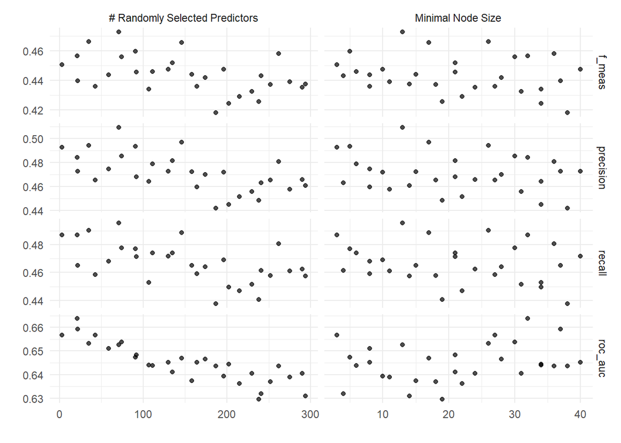

```r
a_tunear_6 |>
  autoplot() +
  theme_minimal()
```

```r
# Mostramos los hiperparámetros que dan la mejor curva ROC
show_best(a_tunear_6, "roc_auc")
```

| mtry | min_n | .metric | .estimator | mean | n | std_err | .config |
| --- | --- | --- | --- | --- | --- | --- | --- |
| 21 | 32 | roc_auc | hand_till | 0.6637545 | 5 | 0.01479147 | Preprocessor1_Model01 |
| 22 | 37 | roc_auc | hand_till | 0.6593497 | 5 | 0.01490386 | Preprocessor1_Model19 |
| 3 | 3 | roc_auc | hand_till | 0.6566721 | 5 | 0.01151878 | Preprocessor1_Model02 |
| 43 | 27 | roc_auc | hand_till | 0.6566260 | 5 | 0.01390099 | Preprocessor1_Model09 |
| 74 | 30 | roc_auc | hand_till | 0.6537177 | 5 | 0.01622677 | Preprocessor1_Model08 |

Si bien no se muestra, probamos con los otros parámetros posibles por si los hiperparámetros pudiesen generar un problema de overfitting. Pero en el set de test, la mejor curva ROC corresponde simultáneamente a los hiperparámetros que producen la mejor curva ROC en el set de train

```r
#best_ROC <- show_best(a_tunear_6, "roc_auc") |>
#  filter(mtry == 74 &
#         min_n == 30)

best_ROC <- select_best(a_tunear_6,
                        "roc_auc")


# Finalizamos el modelo con los hiperparámetros que dan la mejor curva ROC
final_rf <- finalize_model(modelo_a_tunear,
                           best_ROC)

# Modelo final
final_rf
```

```
## Random Forest Model Specification (classification)
##
## Main Arguments:
##   mtry = 21
##   trees = 1000
##   min_n = 32
##
## Computational engine: ranger
```

## Entrenamiento modelo final

```r
# Actualizamos al modelo final
fit_final <- wf |>
  update_model(final_rf) |>
  # Fiteamos a los datos de entrenamiento
  fit(train_embed)
```

## Evaluación sobre test

```r
# Crear un nuevo flujo de trabajo, agregar la receta y el modelo, y ajustar al conjunto de datos de entrenamiento en una sola línea
tree_fit <- workflow() %>%
  add_recipe(receta) %>%
  add_model(final_rf) %>%
  fit(data = train_embed)
```

```r
preds_embed <- test_embed %>%
        select(orientacion) %>%
        bind_cols(predict(tree_fit, test_embed, type="prob")) %>%
        bind_cols(predict(tree_fit, test_embed, type="class"))

print(preds_embed)
```

```
## # A tibble: 90 × 5
##    orientacion .pred_progresista .pred_neutro .pred_conservador .pred_class
##    <fct>                   <dbl>        <dbl>             <dbl> <fct>
##  1 progresista             0.420        0.298             0.282 progresista
##  2 progresista             0.407        0.400             0.193 progresista
##  3 progresista             0.372        0.370             0.258 progresista
##  4 progresista             0.388        0.247             0.365 progresista
##  5 progresista             0.424        0.382             0.194 progresista
##  6 progresista             0.424        0.419             0.157 progresista
##  7 progresista             0.400        0.297             0.303 progresista
##  8 progresista             0.337        0.330             0.333 progresista
##  9 progresista             0.304        0.346             0.350 conservador
## 10 progresista             0.435        0.312             0.252 progresista
## # ℹ 80 more rows
```

```r
metricas_6 <- roc_auc(preds_embed, orientacion, c(.pred_conservador, .pred_neutro, .pred_progresista)) %>%
  bind_rows(accuracy(preds_embed, orientacion, .pred_class)) %>%
  bind_rows(precision(preds_embed, orientacion, .pred_class)) %>%
  bind_rows(recall(preds_embed, orientacion, .pred_class)) %>%
  bind_rows(f_meas(preds_embed, orientacion, .pred_class)) |>
  mutate(modelo = "modelo_6")

metricas_6
```

| .metric | .estimator | .estimate | modelo |
| --- | --- | --- | --- |
| roc_auc | hand_till | 0.4505556 | modelo_6 |
| accuracy | multiclass | 0.5000000 | modelo_6 |
| precision | macro | 0.4968428 | modelo_6 |
| recall | macro | 0.5000000 | modelo_6 |
| f_meas | macro | 0.4905613 | modelo_6 |

## Elimina objetos previos

```r
# Elimina todos los objetos excepto las métricas. A propósito le dejé el "#", así se genera un error si uno pone "run all" y así uno decide, en el momento, si quiere eliminar todos los objetos y hacer las métricas o modificar algo de alguno de los objetos anteriores

todos_los_objetos <- ls()

objetos_a_no_eliminar <- c("metricas_1", "metricas_2", "metricas_3","metricas_4", "metricas_5", "metricas_6")

objetos_a_eliminar <- setdiff(todos_los_objetos, objetos_a_no_eliminar)

rm(list = objetos_a_eliminar)

rm("objetos_a_eliminar", "objetos_a_no_eliminar", "todos_los_objetos")
```

# GRÁFICO 8: COMPARANDO MÉTRICAS DE LOS MODELOS PROBADOS (RANDOM FOREST Y REGRESIÓN LOGÍSTICA REGULARIZADA POR LASSO)

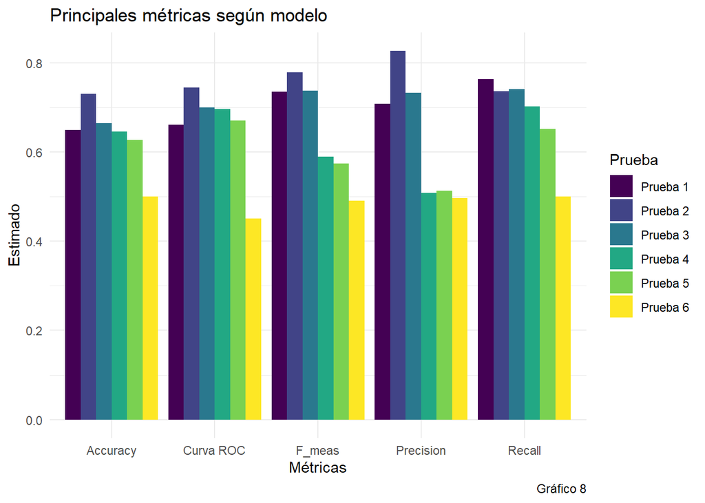

```r
metricas_modelos <- metricas_1 |>
  bind_rows(metricas_2) |>
  bind_rows(metricas_3) |>
  bind_rows(metricas_4) |>
  bind_rows(metricas_5) |>
  bind_rows(metricas_6)


grafico8 <- metricas_modelos |>
  mutate(.metric = case_when(
    .metric == "accuracy" ~ "Accuracy",
    .metric == "roc_auc" ~ "Curva ROC",
    .metric == "precision" ~ "Precision",
    .metric == "recall" ~ "Recall",
    .metric == "f_meas" ~ "F_meas",
    TRUE ~ as.character(.metric))) |>
  mutate(modelo = case_when(
    modelo == "modelo_1" ~ "Prueba 1",
    modelo == "modelo_2" ~ "Prueba 2",
    modelo == "modelo_3" ~ "Prueba 3",
    modelo == "modelo_4" ~ "Prueba 4",
    modelo == "modelo_5" ~ "Prueba 5",
    modelo == "modelo_6" ~ "Prueba 6",
    TRUE ~ as.character(modelo))) |>
  ggplot(aes(x = .metric, y = .estimate, fill = modelo)) +
  geom_col(position = "dodge") +
  scale_fill_viridis_d() +
  labs(title = "Principales métricas según modelo",
       caption = "Gráfico 8",
       plot.title = element_text(size = 10),
       x = "Métricas",
       y = "Estimado") +
  guides(fill = guide_legend(title = "Prueba")) +
  theme_minimal()


print(grafico8)
```

```r
# Guardar el gráfico como un archivo
ggsave(filename = "Graficos/Grafico8.png",
       plot = grafico8,
       width = 8, height = 6)
```